# Data Science Challenge 2020

# Inhaltsverzeichnis:

- Einleitung
- Der verwendete Datensatz
- Übersetzung von R nach Python
  - Definition der Trainings- bzw. Testdaten
  - GLM - Generalized Linear Models
  - CART - Classification and Regression Trees
  - BAGGING - Bootstrap Aggregation
  - RF - Random forests
  - XGB - Gradient Boosting
  - BART - Bayesian Additive Regressions Trees
  - MARS - Multivariate Adaptive Regression Splines
  - Fazit
- Erweiterung der Modellvielfalt um ein neuronales Netz
- Zusammenfassung der Ergebnisse
- Links

# Einleitung

Aufgrund des [Vortrags](https://www.actuview.com/data-science-challenge-2020_354ff90b8.html) von Friedrich Loser im Rahmen der e-Jahrestagung zum Thema 'Data Science Challenge 2020' sind wir auf einen öffentlich zugänglichen Datensatz aufmerksam geworden, der von Mervyn Kopinsky im Rahmen der Studie ['Predicting Group Long Term Disability Recovery and Mortality Rates Using Tree Models'](https://www.soa.org/globalassets/assets/files/research/projects/2017-gltd-recovery-mortality-tree.pdf) verwendet wurde. Dieser Datensatz wurde nun auch in einer weiteren Studie ['Machine-Learning Methods for Insurance Applications - A Survey'](https://www.soa.org/globalassets/assets/files/resources/research-report/2019/machine-learning-methods.pdf) von Alex Diana, Jim E. Griffin, Jaideep Oberoi und Ji Yao verwendet und durch weitere, aus den gegebenen Daten abgeleitete Größen erweitert. Diese Daten dienen auch als Grundlage für diese Arbeit.

Die Studie 'Machine-Learning Methods for Insurance Applications' widmet sich der Fragestellung, wie man neuartige Entwicklungen in der Sammlung von Daten sowie deren Auswertung im Rahmen von 'Data Science' in der aktuariellen Welt nutzbar machen kann. Denn aufgrund wachsender Datenmengen ist es nötig Verfahren zu entwickeln, mit deren Hilfe man diese Datenmenge effizient auswerten kann, indem relevante Variablen in Vorhersagemodellen ausgewählt und falsche Zusammenhänge identifiziert und beseitigt werden. Schadensdaten sind in der Regel spärlich, flüchtig, verzerrt und zeitlich variabel. Dies macht sie zu hervorragenden Kandidaten für die Analyse mit maschinellen Lernansätzen, insbesondere mit variablen Auswahlmethoden.

Neben der Studie 'Machine-Learning Methods for Insurance Applications' selbst wurde auch der verwendete Datensatz inklusive des Jupyter-Notebook veröffentlich, so dass diese Arbeit erst möglich gemacht wurde. Die Ergebnisse der Studie basieren auf der Sprache 'R', sodass das erstes Ziel dieser Arbeit ist, die im Jupyter-Notebook beschriebenen Rechnungen in der Programmiersprache 'Python' wiederzugeben und die Ergebnisse mit denen der Studienautoren zu vergleichen. Wir gehen davon aus, dass keine signifikanten Unterschiede zu erkennen sein werden - oder anders formuliert, dass die Sprachen 'R' und'Python' gleichwertige Ergebnisse liefern.

Neben diesen vorgestellten Methoden beschäftigen wir uns weiterhin mit einem Random Forest. Innerhalb des Vergleichs zwischen den beiden Programmiersprachen wird ebenfalls ein Modell dieser Art verwendet. Bei einem Random Forest handelt es sich um eine weit verbreitete Methode, die im Rahmen der Analyse von Daten und den daraus abgeleiteteten Vorhersagen benutzt wird. Wir wollen daher einige Schritte vorstellen, die man ergreifen kann, um eine bessere Vorhersage zu erhalten.

Die Studie untersucht und vergleicht verschiedene Machine-Learning-Methoden miteinander. Dabei fällt auf, dass künstiche neuronale Netze nur sehr kurz behandelt werden. Die Autoren haben ein einfaches neuronales Netz untersucht, welches im Vergleich zu den anderen Methoden schlechte Ergebnisse liefert, stellen jedoch heraus, dass künstliche neuronale Netze in der Vergangenheit bereits sehr gute Ergebnisse erzielt haben. Unser zweites Ziel ist daher die Entwicklung eines künstlichen neuronalen Netzes, welches eine mindestens ähnliche Güte im Vergleich zu den anderen Machine-Learning-Methoden aufweist. Die Ergebnisse des neuronalen Netzes werden abschließend mit den Ergebnissen der Studie verglichen.

Diese Arbeit gliedert sich demnach in die drei Ziele:

1. Übersetzung der bereits untersuchten Machine-Learning Methoden von 'R' nach 'Python'.
2. Untersuchung des Random-Forests auf Verbesserungsmöglichkeiten.
3. Aufbau und Training eines künstlichen neuronalen Netzes.

Zunächst laden wir alle Pakete, die wir für unsere Analysen benutzen:

```python
import pandas as pd
seed_value= 1
import os
os.environ['PYTHONHASHSEED']=str(seed_value)
import random
random.seed(seed_value)
import numpy as np
np.random.seed(seed_value)
import tensorflow as tf
tf.random.set_seed(seed_value)
from tensorflow import keras
from keras.wrappers.scikit_learn import KerasClassifier
import kerastuner as kt
import IPython
import matplotlib.pyplot as plt
import math
import statsmodels.formula.api as smf
import statsmodels.api as sm
import datetime
import xgboost as xgb
import graphviz
import pyearth
from sklearn.model_selection import GridSearchCV
from sklearn.model_selection import RandomizedSearchCV
from sklearn.ensemble import RandomForestRegressor
from sklearn.metrics import mean_squared_error
from sklearn import tree
from pprint import pprint
from xgboost import plot_tree
!pip install gbart
import gbart
from gbart.modified_bartpy.sklearnmodel import SklearnModel
```

```
     |████████████████████████████████| 40 kB 175 kB/s
```

# Der verwendete Datensatz

In diesem Abschnitt wollen wir uns mit den Variablen der beiden Modelle beschäftigen, um zu erläutern welche Art von Daten in die Modelle eingeflossen sind. Es ist wichtig zu verstehen, welche Daten vorliegen, um entsprechende Modelle fundiert zu definieren und zu analysieren. In beiden Fällen liegen bereits strukturierte Datensätze vor, so dass wir die Daten an dieser Stelle nicht zunächst in eine strukturierte Form überführen müssen. Wir können also direkt dazu übergehen den Datensatz spaltenweise zu betrachten und die in den jeweiligen Spalten enthaltenen Informationen zu beschreiben.

Im Rahmen dieser Arbeit benutzen wir die gegebenen Daten aus der Studie, ohne diese auf ihren kausalen Zusammenhang zu untersuchen. Wir nehmen an, dass die Daten, die zur Bildung der Modelle aus dem nächsten Abschnitt verwendet werden, bereits hinreichend geprüft wurden. D.h. wir gehen davon aus, dass die benutzten Variablen signifikanten Einfluss auf die Ergebnisse des Modells haben, sowie alle nicht verwendeten Daten diesen Einfluss nicht aufweisen.

Desweiteren haben wir die Qualität der Daten nicht geprüft. Denn wie in der Einleitung bereits beschrieben ist ein Ziel dieser Arbeit, die Modelle, die in der Sprache 'R' geschrieben wurden, gegen identische Modelle in der Sprache 'Python' zu testen. Ebenfalls ist für die Erweiterung durch ein künstliches neuronales Netz und den angestrebten Vergleich mit den existierenden Modellen entscheidend, dass die gleiche Datengrundlage verwendet wird.

Dennoch möchten wir an dieser Stelle zeigen, wie die Ausprägungen der verwendeten Variablen beschrieben sind. Dazu verwenden wir gezielt zur Darstellung passend gewählte Visualisierungsformen. Wir betrachten dabei nur die Variablen, die für die Modelle des nächsten Abschnitts relevant sind.

Wir lesen den Datensatz für die weitere Bearbeitung ein. Als Grundlage dieser Arbeit dient der frei verfügbare Datensatz 'recovery', der zur Studie ['Machine-Learning Methods for Insurance Applications - A Survey'](https://www.soa.org/globalassets/assets/files/resources/research-report/2019/machine-learning-methods.pdf) gehört und [hier](https://www.soa.org/resources/research-reports/2019/machine-learning-methods/) heruntergeladen werden kann.

```python
# Einlesen der Dateien
recovery = pd.read_csv('../input/gltdtestdata/2017-gltd-tree-recovery-rate-input-data.csv')
```

Im folgenden wollen wir uns dem verwendeten Datensatz ein wenig nähern und diesen zunächst analysieren. Dabei betrachten wir die Größe des Datensatzes und deren einzelne Parameter inkl. der zugehörigen Ausprägungen.

```python
# Anzahl der Datensätze
pprint("Anzahl der Datenätze in 'recovery' entspricht: " + str(len(recovery)))
```

```
"Anzahl der Datenätze in 'recovery' entspricht: 818941"
```

Der Datensatz besitzt die folgendenen Spalten mit den nachfolgenden Ausprägungen. Zu Details zu der Erhebung, dem Preprocessing und der Bedeutung der Daten verweisen wir auf die Studie ['Predicting Group Long Term Disability Recovery and Mortality Rates Using Tree Models'](https://www.soa.org/globalassets/assets/files/research/projects/2017-gltd-recovery-mortality-tree.pdf).

```python
pprint(list(recovery.columns))
```

```
['Unnamed: 0',
 'Duration_12_49',
 'AgeBand',
 'Disability_Category',
 'OwnOccToAnyTransition_MOD',
 'Integration_with_STD',
 'Taxability_Benefits',
 'Gender',
 'Gross_Indexed_Benefit_Amount',
 'Exposures',
 'Actual_Recoveries',
 'Expected_Recoveries',
 'Actual_Deaths',
 'Expected_Deaths',
 'Actual_Recovery_Rate']
```

```python
pprint(recovery['Duration_12_49'].unique())
```

```
array([ 2,  3,  4,  5,  6,  7,  8,  9, 10, 11, 12, 13, 14, 15, 16, 17, 18,
       19, 20, 21, 22, 23, 24, 25, 26, 27, 28, 29, 30, 31, 32, 33, 34, 35,
       36, 37, 38, 39, 40, 41, 42, 43, 44, 45, 46, 47, 48, 49])
```

```python
pprint(recovery['AgeBand'].unique())
```

```
array([20, 25, 30, 35, 40, 45, 50, 55, 60, 65, 70])
```

```python
pprint(recovery['Disability_Category'].unique())
```

```
array(['Back', 'Cancer', 'Circulatory', 'Digestive',
       'Ill-defined and Misc Conditions', 'Injury other than back',
       'Maternity', 'Mental and Nervous', 'Nervous System', 'Other',
       'Other Musculoskeletal', 'Respiratory', 'Diabetes'], dtype=object)
```

```python
pprint(recovery['OwnOccToAnyTransition_MOD'].unique())
```

```
array(['OwnOther', 'Own+1', 'Own+0'], dtype=object)
```

```python
pprint(recovery['Integration_with_STD'].unique())
```

```
array(['I: Integrated with ASO of Fully-Insured STD',
       'N: Not Integrated with STD', 'U: Unknown'], dtype=object)
```

```python
pprint(recovery['Taxability_Benefits'].unique())
```

```
array(['T: 100% Taxable', 'Unknown/Invalid', 'N: Non-Taxable',
       'P: Partial Taxability'], dtype=object)
```

```python
pprint(recovery['Gender'].unique())
```

```
array(['2:Female', '1: Male'], dtype=object)
```

```python
pprint(recovery['Gross_Indexed_Benefit_Amount'].unique())
```

```
array(['1: $ < 1000', '2: $1,000 - $1,999', '3: $2,000 - $2,999',
       '4: $3,000 - $3,999', '5: $4,000 - $4,999', '6: $5,000 - $9,999',
       'Unknown', '7:$10,000 - $14,999', '9:$20,000 And Over',
       '8:$15,000 - $19,999'], dtype=object)
```

Um ein Gefühl für die Ausprägungen der Variablen zu bekommen, sind die Häufigkeiten ihres Auftretens nachfolgend in Histogrammen geplottet. In den Histogrammen wird deutlich, dass in etwa ähnlich viele Männer wie Frauen teilgenommen haben. Die am häufigsten auftretende Altergruppen liegt zwischen 50 und 60 Jahren. Insgesamt werden 13 Gründe untersucht, weshalb jemand berufusunfähig geworden ist, wobei am häufigsten die Ursache "back" angegeben wurde. Insbesondere erkennt man auch, dass die Tatsächliche Recovery Rate sehr schief verteilt ist mit einer Häufung bei 0.

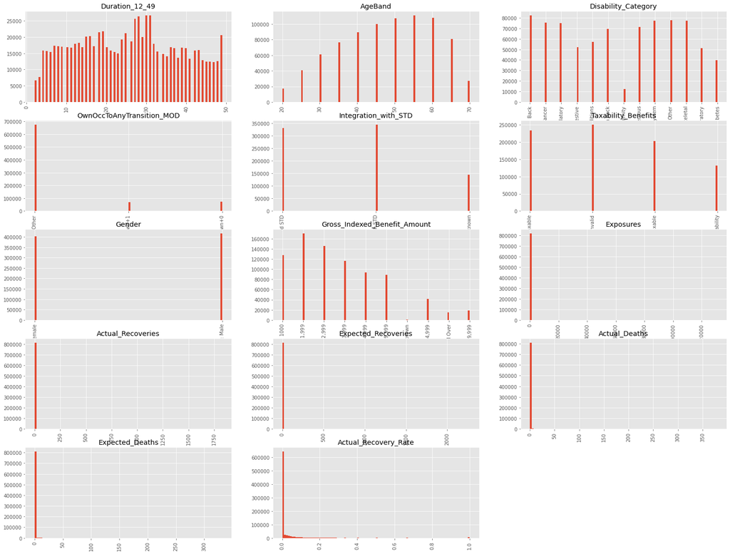

```python
diagramm = plt.figure(figsize=(30,8))
plt.style.use('ggplot')
plt.subplots_adjust(bottom=0.1, right=0.8, top=2)

# Duration_12_49
dDuration = recovery['Duration_12_49']
aDuration = diagramm.add_subplot(5,3,1)
plt.xticks(rotation=90)
plt.title('Duration_12_49')
plt.hist(dDuration, bins=100)

# AgeBand
dAgeBand = recovery['AgeBand']
aAgeBand = diagramm.add_subplot(5,3,2)
plt.xticks(rotation=90)
plt.title('AgeBand')
plt.hist(dAgeBand, bins=100)

# Disability_Category
dDisCat = recovery['Disability_Category']
aDisCat = diagramm.add_subplot(5,3,3)
plt.xticks(rotation=90)
plt.title('Disability_Category')
plt.hist(dDisCat, bins=100)

# OwnOccToAnyTransition_MOD
dOwnOCC = recovery['OwnOccToAnyTransition_MOD']
aOwnOCC = diagramm.add_subplot(5,3,4)
plt.xticks(rotation=90)
plt.title('OwnOccToAnyTransition_MOD')
plt.hist(dOwnOCC, bins=100)

# Integration_with_STD
dIntSTD = recovery['Integration_with_STD']
aIntSTD = diagramm.add_subplot(5,3,5)
plt.xticks(rotation=90)
plt.title('Integration_with_STD')
plt.hist(dIntSTD, bins=100)

# Taxability_Benefits
dTaxBen = recovery['Taxability_Benefits']
aTaxBen = diagramm.add_subplot(5,3,6)
plt.xticks(rotation=90)
plt.title('Taxability_Benefits')
plt.hist(dTaxBen, bins=100)

# Gender
dGender = recovery['Gender']
aGender = diagramm.add_subplot(5,3,7)
plt.xticks(rotation=90)
plt.title('Gender')
plt.hist(dGender, bins=100)

# Gross_Indexed_Benefit_Amount
dGIBA = recovery['Gross_Indexed_Benefit_Amount']
aGIBA = diagramm.add_subplot(5,3,8)
plt.xticks(rotation=90)
plt.title('Gross_Indexed_Benefit_Amount')
plt.hist(dGIBA, bins=100)

# Exposures
dExposures = recovery['Exposures']
aExposures = diagramm.add_subplot(5,3,9)
plt.xticks(rotation=90)
plt.title('Exposures')
plt.hist(dExposures, bins=100)

# Actual_Recoveries
dActRec = recovery['Actual_Recoveries']
aActRec = diagramm.add_subplot(5,3,10)
plt.xticks(rotation=90)
plt.title('Actual_Recoveries')
plt.hist(dActRec, bins=100)

# Expected_Recoveries
dExpRec = recovery['Expected_Recoveries']
aExpRec = diagramm.add_subplot(5,3,11)
plt.xticks(rotation=90)
plt.title('Expected_Recoveries')
plt.hist(dExpRec, bins=100)

# Actual_Deaths
dActDeaths = recovery['Actual_Deaths']
aActDeaths = diagramm.add_subplot(5,3,12)
plt.xticks(rotation=90)
plt.title('Actual_Deaths')
plt.hist(dActDeaths, bins=100)

# Expected_Deaths
dExpDeaths = recovery['Expected_Deaths']
aExpDeaths = diagramm.add_subplot(5,3,13)
plt.xticks(rotation=90)
plt.title('Expected_Deaths')
plt.hist(dExpDeaths, bins=100)

# Actual_Recovery_Rate
dActRecRate = recovery['Actual_Recovery_Rate']
aActRecRate = diagramm.add_subplot(5,3,14)
plt.xticks(rotation=90)
plt.title('Actual_Recovery_Rate')
plt.hist(dActRecRate, bins=100)

plt.show()
```

Analog zum Vorgehen der SOA haben wir die Actual Recovery Rate aufgrund der schiefen Verteilung für die Datenpunkte unter Ausschluss der Personen mit einer Actual Recovery Rate in Höhe von 0.0 zusätzlich geplottet.

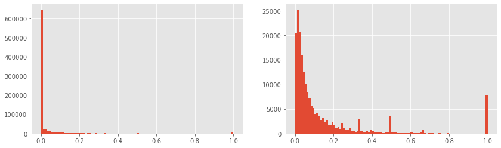

```python
diagramm = plt.figure(figsize=(14,4))
plt.style.use('ggplot')
# mit 0-Werte
dActRec = recovery['Actual_Recovery_Rate']
aActRec = diagramm.add_subplot(1,2,1)
plt.hist(dActRec, bins=100)

# ohne 0-Werte
np.count_nonzero(recovery['Actual_Recovery_Rate']==0)/ len(recovery['Actual_Recovery_Rate'])
#76%  of the values of Actual_Recovery_Rate are equal to  0 . A histogram of the actual recovery rate is presented next:
dActRecoverRatePos = [x for x in recovery['Actual_Recovery_Rate'] if x != 0]
aActRecoverRatePos = diagramm.add_subplot(1,2,2)
plt.hist(dActRecoverRatePos, bins=100)
plt.show()
```

# Übersetzung von R nach Python

Im folgenden werden die Ergebnisse der SOA in der Programmiersprache "Python" reproduziert. Zunächst werden die Trainings- & Testdaten eingelesen. Danach folgt die Analyse der folgenden Machine-Learning Verfahren:

- GLM - Generalized Linear Models
- CART - Classification and Regression Trees
- BAGGING - Bootstrap Aggregation
- RF - Random forests
- XGB - Gradient Boosting
- BART - Bayesian Additive Regressions Trees
- MARS - Multivariate Adaptive Regression Splines

Auf die genaue Beschreibung der reproduzierten Machine Learning Methoden verzichten wir aus Gründen Übersichtlichkeit an dieser Stelle und verweisen auf den Bericht der SOA.

Zunächst definieren wir für die einzelnen Modelle noch eine Methode, die uns die Ergebnisse des jeweiligen Modells anzeigen kann.

```python
def output(model, python_mse, r_mse):
    try:
        python_mse
        r_mse
    except NameError:
        print(model + ": Nicht erfolgreich ausgeführt. Variablen unbekannt.")
    else:
        print(model + ": Erfolgreich ausgeführt")
        print(model + ": Ergebnis mse = " + str(python_mse))
        if r_mse != None:
            print(model + ": Abwechung zum entsprechenden Modell in 'R':" + str(python_mse - r_mse))
            if python_mse - r_mse < 0:
                print(model + ": Das Modell in 'Python' ist besser!")
            elif python_mse == r_mse:
                print(model + ": Die Modelle sind gleichwertig!")
            else:
                print(model + ": Das Modell in 'R' ist besser!")
```

Da wir den Großteil der Elemente dieser Arbeit in Kaggle entwickelt haben, definieren wir um die Laufzeit zu verkürzen einen boolschen Wert 'mitBerechnung'. Weißt dieser den Wert 'True' auf, so werden alle Berechnungen innerhalb dieses Notebooks ausgeführt, ist der Wert hingegen 'False', so greifen wir auf Werte zurück, die wir in einer der vorherigen Versionen des Notebooks erzeugt haben. Natürlich werden nicht alle Ergebnisse in jeder Ausführung auch wieder exakt getroffen. Die Variationen erschienen uns allerdings vernachlässigbar.

```python
mitBerechnung = False
```

# Definition der Trainings- bzw. Testdaten

Zielgröße ist die Variable "Actual_Recovery_Rate". Die untersuchten Einflussgrößen sind die sieben Variablen:

1. Duration
2. Age
3. Gender
4. Disability Category
5. Own to Any Occupation Transition
6. Gross Indexed Benefit Amount
7. Integration with STD

Zum Trainieren der Machine-Learning-Methoden werden Trainingsdaten benötigt. Zusätzlich dazu werden Testdaten ermittelt anhand derer die Performance der verschiedenen Methoden gemessen wird. Um die Ergebnisse vergleichbar zu machen, haben wir den Trainingsdatensatz der SOA aus R exportiert und hier wieder importiert. Alternativ können an dieser Stelle neue Trainingsdaten erzeugt werden, indem zufällig 70% der Datenpunkte als Trainingsdatensatz ausgewählt und die verbleibenden 30% als Testdatensatz verwendet werden.

```python
# Generierung einer neuen Testmenge mit 1, lesen der CSV-Dateien mit 0
x = 0
if x == 1:
    recoveryMod = recovery.loc[:,
        ('Actual_Recovery_Rate', 'AgeBand', 'Duration_12_49', 'Gross_Indexed_Benefit_Amount', 'Disability_Category',
         'OwnOccToAnyTransition_MOD', 'Integration_with_STD', 'Gender')]
    # mischen der Daten
    random.seed(1)
    index= list(range(0,recoveryMod.shape[0]))
    random.shuffle(index)
    # 70% der Daten werden zum Trainieren verwendet:
    train_sample = math.floor(0.7 * len(recoveryMod))
    datatrain = recoveryMod.iloc[index[:train_sample], :]
    datatest = recoveryMod.iloc[index[train_sample:], :]
else:
    datatrain_full = pd.read_csv('../input/gltdtestdata/dataTrain.csv')
    datatrain = datatrain_full[['Actual_Recovery_Rate','AgeBand', 'Duration_12_49', 'Gross_Indexed_Benefit_Amount', 'Disability_Category', 'OwnOccToAnyTransition_MOD', 'Integration_with_STD', 'Gender']]
    datatest_full = pd.read_csv('../input/gltdtestdata/dataTest.csv')
    datatest = datatest_full[['Actual_Recovery_Rate','AgeBand', 'Duration_12_49', 'Gross_Indexed_Benefit_Amount', 'Disability_Category', 'OwnOccToAnyTransition_MOD', 'Integration_with_STD', 'Gender']]

x_train = datatrain.loc[:, datatrain.columns!='Actual_Recovery_Rate']
x_train_ohe = pd.get_dummies(x_train)
y_train = datatrain.loc[:, datatrain.columns=='Actual_Recovery_Rate']
x_test = datatest.loc[:, datatest.columns!='Actual_Recovery_Rate']
x_test_ohe = pd.get_dummies(x_test)
y_test = datatest.loc[:, datatrain.columns=='Actual_Recovery_Rate']

print("Trainings- und Testdaten erfolgreich generiert.")
```

```
Trainings- und Testdaten erfolgreich generiert.
```

## GLM - Generalized Linear Models

```python
# GLM 1
if mitBerechnung:
    # Zeitmessung starten
    start_time = datetime.datetime.now()

    formula = 'Actual_Recovery_Rate ~ AgeBand + Duration_12_49 + Gross_Indexed_Benefit_Amount + Disability_Category + OwnOccToAnyTransition_MOD + Integration_with_STD + Gender'
    model = smf.glm(formula = formula, data=datatrain, family= sm.families.Gaussian())  #sm.families.Gaussian(sm.families.links.identity))
    result = model.fit()
    ypred = result.predict(datatest)
    mse_glm1 = ((ypred - datatest['Actual_Recovery_Rate'])**2).mean(axis=None)

    # Zeitmessung beenden
    end_time = datetime.datetime.now()

    # verbrauchte Zeit berechnen
    elapsed_time = end_time - start_time
    t_glm1 = elapsed_time.total_seconds()
else:
    mse_glm1 = 0.013338525987274875
    t_glm1 = 16.404506

# Vergleichswerte aus R
r_mse_glm1 = 0.01333853
r_t_glm1 = 3.230486

# Output
output("GLM 1", mse_glm1, r_mse_glm1)
```

```
GLM 1: Erfolgreich ausgeführt
GLM 1: Ergebnis mse = 0.013338525987274875
GLM 1: Abwechung zum entsprechenden Modell in 'R':-4.01272512440265e-09
GLM 1: Das Modell in 'Python' ist besser!
```

```python
# GLM 2
if mitBerechnung:
    # Zeitmessung starten
    start_time = datetime.datetime.now()

    formula_model1 = """Actual_Recovery_Rate2 ~ Disability_Category
                            + AgeBand + Duration_12_49 + OwnOccToAnyTransition_MOD
                            + Integration_with_STD + Gender + Gross_Indexed_Benefit_Amount"""

    data_mod = datatrain
    data_mod.loc[:,'Actual_Recovery_Rate2'] = np.where(datatrain.loc[:,'Actual_Recovery_Rate'] > 0, 1, 0)
    glm_model1 = smf.glm(formula=formula_model1, data=data_mod, family=sm.families.Binomial())
    result1 = glm_model1.fit()

    prediction1 = result1.predict(datatest)
    glm_prediction = np.where(prediction1 > 0.5, 1, 0)

    data_mod_log  = datatrain[datatrain['Actual_Recovery_Rate'] != 0]
    data_mod_log.loc[:]['Actual_Recovery_Rate'] = np.log(data_mod_log['Actual_Recovery_Rate'])
    formula_model2 = 'Actual_Recovery_Rate ~ Disability_Category + AgeBand + Duration_12_49 + OwnOccToAnyTransition_MOD + Integration_with_STD + Gender + Gross_Indexed_Benefit_Amount'
    glm_model2 = smf.glm(formula=formula_model2, data=data_mod_log,family=sm.families.Gaussian())

    result2 = glm_model2.fit()

    indices = [i for i, v in enumerate(glm_prediction) if glm_prediction[i] > 0]
    testset = datatest.loc[:,datatest.columns != 'Actual_Recovery_Rate']
    testset = testset.loc[indices]

    prediction = np.where(prediction1==1, 1.0, 0.0)

    prediction2 = result2.predict(testset)
    glm_prediction = np.exp(np.array(prediction2))
    for i, v in enumerate(indices):
        prediction[v] =  glm_prediction[i]

    mse_glm2 = ((prediction - datatest['Actual_Recovery_Rate']) ** 2).mean(axis=None)

    # Zeitmessung beenden
    end_time = datetime.datetime.now()

    # verbrauchte Zeit berechnen
    elapsed_time = end_time - start_time
    t_glm2 = elapsed_time.total_seconds()
else:
    mse_glm2 = 0.014760995460538455
    t_glm2 = 21.370961

# Vergleichswerte aus R
r_mse_glm2 = 0.014761
r_t_glm2 = 9.107313

# Output
output("GLM 2", mse_glm2, r_mse_glm2)
```

```
GLM 2: Erfolgreich ausgeführt
GLM 2: Ergebnis mse = 0.014760995460538455
GLM 2: Abwechung zum entsprechenden Modell in 'R':-4.539461544508794e-09
GLM 2: Das Modell in 'Python' ist besser!
```

```python
# GLM 3
if mitBerechnung:
    # Zeitmessung starten
    start_time = datetime.datetime.now()

    formula_model3 = 'Actual_Recovery_Rate ~ (Disability_Category + AgeBand + Duration_12_49 + OwnOccToAnyTransition_MOD + Integration_with_STD + Gender + Gross_Indexed_Benefit_Amount)*(Disability_Category + AgeBand + Duration_12_49 + OwnOccToAnyTransition_MOD + Integration_with_STD + Gender + Gross_Indexed_Benefit_Amount)'

    glm_model3 = smf.glm(formula = formula_model3, data = datatrain, family = sm.families.Gaussian())

    glm_result3 = glm_model3.fit()
    glm_predictions3 = glm_result3.predict(datatest)

    mse_glm3 = ((glm_predictions3 - datatest['Actual_Recovery_Rate'])**2).mean(axis=None)

    # Zeitmessung beenden
    end_time = datetime.datetime.now()

    # verbrauchte Zeit berechnen
    elapsed_time = end_time - start_time
    t_glm3 = elapsed_time.total_seconds()
else:
    mse_glm3 = 0.012837709032298566
    t_glm3 = 85.949018

# Vergleichswerte aus R
r_mse_glm3 = 0.01283771
r_t_glm3 = 94.1341

# Output
output("GLM 3", mse_glm3, r_mse_glm3)
```

```
GLM 3: Erfolgreich ausgeführt
GLM 3: Ergebnis mse = 0.012837709032298566
GLM 3: Abwechung zum entsprechenden Modell in 'R':-9.67701434609336e-10
GLM 3: Das Modell in 'Python' ist besser!
```

## CART - Classification and Regression Trees

```python
# CART
if mitBerechnung:
    # Zeitmessung starten
    start_time = datetime.datetime.now()

    regressor = tree.DecisionTreeRegressor(max_depth = 15, min_samples_leaf = 110, min_impurity_decrease = 0.0000001)
    regressor.fit(x_train_ohe.values, y_train.values.ravel())

    predictions = regressor.predict(x_test_ohe.values)

    mse_cart = ((predictions - datatest['Actual_Recovery_Rate'])**2).mean(axis=None)

    # Zeitmessung beenden
    end_time = datetime.datetime.now()

    # verbrauchte Zeit berechnen
    elapsed_time = end_time - start_time
    t_cart = elapsed_time.total_seconds()
else :
    mse_cart = 0.012192802558206421
    t_cart = 3.261407

# Vergleichswerte aus R
r_mse_cart = 0.0121376
r_t_cart = 90.17855

# Output
output("CART", mse_cart, r_mse_cart)
```

```
CART: Erfolgreich ausgeführt
CART: Ergebnis mse = 0.012192802558206421
CART: Abwechung zum entsprechenden Modell in 'R':5.5202558206421046e-05
CART: Das Modell in 'R' ist besser!
```

```python
if mitBerechnung:
    dot_data = tree.export_graphviz(regressor, out_file=None,
                filled=True, rounded=True,
                special_characters=True)

    graph = graphviz.Source(dot_data)
    graph
```

## BAGGING - Bootstrap Aggregation

```python
# bagging
if mitBerechnung:
    # Zeitmessung starten
    start_time = datetime.datetime.now()
    tree_sequence = range(50,500,5)
    MSE_bag = []

    for i in tree_sequence:
        n_estimators = i
        regressor = RandomForestRegressor(n_estimators, min_samples_split = 150, max_features=3)
        regressor.fit(x_train_ohe.values, y_train.values.ravel())
        predictions = regressor.predict(x_test_ohe.values)
        MSE_bag.append(((predictions - datatest['Actual_Recovery_Rate'])**2).mean(axis=None))

    mse_bag = np.mean(MSE_bag)

    # Zeitmessung beenden
    end_time = datetime.datetime.now()

    # verbrauchte Zeit berechnen
    elapsed_time = end_time - start_time
    t_bag = elapsed_time.total_seconds()
else:
    mse_bag = 0.012138850493853439
    t_bag = 14259.258127

# Vergleichswerte aus R
r_mse_bag = 0.01210185
r_t_bag = 19205.32

# Output
output("BAG", mse_bag, r_mse_bag)
```

```
BAG: Erfolgreich ausgeführt
BAG: Ergebnis mse = 0.012138850493853439
BAG: Abwechung zum entsprechenden Modell in 'R':3.7000493853437885e-05
BAG: Das Modell in 'R' ist besser!
```

```python
if mitBerechnung:
    x = pd.to_numeric(tree_sequence)
    y = pd.to_numeric(MSE_bag)

    diagramm = plt.figure(figsize=(6,6))
    plt.style.use('ggplot')

    plt.plot(x,y,'o', label="MSE")
    plt.title('Übersicht der MSE')
    plt.ylabel('MSE')
    plt.xlabel('Anzahl der Bäume')
    plt.show()
```

## RF - Random forests

```python
# RF
if mitBerechnung:
    # Zeitmessung starten
    start_time = datetime.datetime.now()

    regressor = RandomForestRegressor(n_estimators=250, min_samples_split = 150, max_features=3)
    regressor.fit(x_train_ohe.values, y_train.values.ravel())

    predictions = regressor.predict(x_test_ohe.values)

    mse_rf = ((predictions - datatest['Actual_Recovery_Rate'])**2).mean(axis=None)

    # Zeitmessung beenden
    end_time = datetime.datetime.now()

    # verbrauchte Zeit berechnen
    elapsed_time = end_time - start_time
    t_rf = elapsed_time.total_seconds()
else:
    mse_rf = 0.012137927171212553
    t_rf = 153.292926

# Vergleichswerte aus R
r_mse_rf = 0.01238596
r_t_rf = 91.52749

# Output
output("RF", mse_rf, r_mse_rf)
```

```
RF: Erfolgreich ausgeführt
RF: Ergebnis mse = 0.012137927171212553
RF: Abwechung zum entsprechenden Modell in 'R':-0.0002480328287874471
RF: Das Modell in 'Python' ist besser!
```

## XGB - Gradient Boosting

```python
# GradBoost
if mitBerechnung:
    # Zeitmessung starten
    start_time = datetime.datetime.now()

    xgbtrain = xgb.DMatrix(x_train_ohe.values, label=y_train)
    xgbtest = xgb.DMatrix(x_test_ohe.values, label=y_test)

    param = {'max_depth': 4,  'eta': 0.3}
    num_round = 1000  # the number of training iterations

    xgb_result = xgb.train(param, xgbtrain, num_round)

    xgb_predictions = xgb_result.predict(xgbtest)

    mse_xgb = ((xgb_predictions - datatest['Actual_Recovery_Rate'])**2).mean(axis=None)

    # Zeitmessung beenden
    end_time = datetime.datetime.now()

    # verbrauchte Zeit berechnen
    elapsed_time = end_time - start_time
    t_xgb = elapsed_time.total_seconds()
else:
    mse_xgb = 0.012083109223432047
    t_xgb = 306.127362

# Vergleichswerte aus R
r_mse_xgb = 0.01211466
r_t_xgb = 443.8047

# Output
output("XGB", mse_xgb, r_mse_xgb)
```

```
XGB: Erfolgreich ausgeführt
XGB: Ergebnis mse = 0.012083109223432047
XGB: Abwechung zum entsprechenden Modell in 'R':-3.1550776567952285e-05
XGB: Das Modell in 'Python' ist besser!
```

```python
if mitBerechnung:
    plot_tree(xgb_result, rankdir='LR')
    fig = plt.gcf()
    fig.set_size_inches(30, 15)
```

## BART - Bayesian Additive Regressions Trees

```python
# BART
if mitBerechnung:
    # Zeitmessung starten
    start_time = datetime.datetime.now()

    bart_model = SklearnModel(sublist=None,
                     n_trees=5,
                     n_chains=4,
                     n_samples=50,
                     n_burn=200,
                     thin=0.1,
                     n_jobs=1)

    bart_result = bart_model.fit(x_train_ohe.values, y_train.values.ravel())

    bart_predictions = bart_model.predict(x_test_ohe.values)

    mse_bart = ((bart_predictions - datatest['Actual_Recovery_Rate'])**2).mean(axis=None)

    # Zeitmessung beenden
    end_time = datetime.datetime.now()

    # verbrauchte Zeit berechnen
    elapsed_time = end_time - start_time
    t_bart = elapsed_time.total_seconds()
else:
    mse_bart = 0.012872875439113165
    t_bart = 591.842287

# Vergleichswerte aus R
r_mse_bart = 0.01210205
r_t_bart = 7284.637

# Output
output("BART", mse_bart, r_mse_bart)
```

```
BART: Erfolgreich ausgeführt
BART: Ergebnis mse = 0.012872875439113165
BART: Abwechung zum entsprechenden Modell in 'R':0.0007708254391131653
BART: Das Modell in 'R' ist besser!
```

## MARS - Multivariate Adaptive Regression Splines

```python
# MARS
if mitBerechnung:
    # Zeitmessung starten
    start_time = datetime.datetime.now()

    mars_model = pyearth.Earth()

    mars_result = mars_model.fit(x_train_ohe,y_train)

    mars_prediction = mars_result.predict(x_test_ohe)

    mse_mars = ((mars_prediction - datatest['Actual_Recovery_Rate'])**2).mean(axis=None)

    # Zeitmessung beenden
    end_time = datetime.datetime.now()

    # verbrauchte Zeit berechnen
    elapsed_time = end_time - start_time
    t_mars = elapsed_time.total_seconds()
else:
    mse_mars = 0.013400830351710476
    t_mars = 32.620724

# Vergleichswerte aus R
r_mse_mars = 0.01242511
r_t_mars = 763.7243

# Output
output("MARS", mse_mars, r_mse_mars)
```

```
MARS: Erfolgreich ausgeführt
MARS: Ergebnis mse = 0.013400830351710476
MARS: Abwechung zum entsprechenden Modell in 'R':0.0009757203517104761
MARS: Das Modell in 'R' ist besser!
```

# Fazit

Bevor wir ein Fazit ziehen, fassen wir zunächst die Ergebnisse der vorangegangenen Modelle in einer übersichtlichen Art und Weise zusammen. Die Vergleichswerte der Sprache 'R' erhalten wir dabei aus dem Jupyter-Notebook zu der Studie 'Machine-Learning Methods for Insurance Applications', welches ebenfalls frei zugänglich ist. Auf Wunsch können wir die Version, die wir zum Erstellen der Ergebniswerte verwendet haben, gerne zur Verfügung stellen.

```python
# Zusammenfassung der Ergebnisse und definieren der Vergleichswerte
python_MSE_data = [('GLM1', mse_glm1 , t_glm1 , 'sec' ) , # Modell, MSE, Time, Zeiteinheit
         ('GLM2', mse_glm2 , t_glm2 , 'sec' ) ,
         ('GLM3', mse_glm3 , t_glm3 , 'sec' ) ,
         ('CART', mse_cart , t_cart , 'sec' ) ,
         ('BAG', mse_bag , t_bag , 'sec' ) ,
         ('RF', mse_rf , t_rf , 'sec' ) ,
         ('XGB', mse_xgb , t_xgb , 'sec' ) ,
         ('BART', mse_bart , t_bart , 'sec' ) ,
         ('MARS', mse_mars , t_mars , 'sec' )]

python_MSE = pd.DataFrame(python_MSE_data, columns=["Methode", "MSE", "Zeit", "Einheit"])

r_MSE_data = [ ('GLM1', r_mse_glm1 , r_t_glm1 , 'sec'),
              ('GLM2', r_mse_glm2 , r_t_glm2 , 'sec'),
              ('GLM3', r_mse_glm3 , r_t_glm3 , 'sec'),
              ('CART', r_mse_cart , r_t_cart , 'sec'),
              ('BAG', r_mse_bag , r_t_bag , 'sec'),
              ('RF', r_mse_rf , r_t_rf , 'sec'),
              ('XGB', r_mse_xgb , r_t_xgb , 'sec'),
              ('BART', r_mse_bart , r_t_bart , 'sec'),
              ('MARS', r_mse_mars , r_t_mars , 'sec')]

r_MSE = pd.DataFrame(r_MSE_data, columns=["Methode", "MSE", "Zeit", "Einheit"])

pprint("Die Ergebnisse in Python:")
pprint(python_MSE)
pprint("Die Ergebnisse in R:")
pprint(r_MSE)
```

```
'Die Ergebnisse in Python:'
  Methode       MSE          Zeit Einheit
0    GLM1  0.013339     16.404506     sec
1    GLM2  0.014761     21.370961     sec
2    GLM3  0.012838     85.949018     sec
3    CART  0.012193      3.261407     sec
4     BAG  0.012139  14259.258127     sec
5      RF  0.012138    153.292926     sec
6     XGB  0.012083    306.127362     sec
7    BART  0.012873    591.842287     sec
8    MARS  0.013401     32.620724     sec
'Die Ergebnisse in R:'
  Methode       MSE          Zeit Einheit
0    GLM1  0.013339      3.230486     sec
1    GLM2  0.014761      9.107313     sec
2    GLM3  0.012838     94.134100     sec
3    CART  0.012138     90.178550     sec
4     BAG  0.012102  19205.320000     sec
5      RF  0.012386     91.527490     sec
6     XGB  0.012115    443.804700     sec
7    BART  0.012102   7284.637000     sec
8    MARS  0.012425    763.724300     sec
```

Sowohl in den beiden Tabellen als auch bereits durch den obigen Output der jeweiligen Modelle, sehen wir, dass der Vergleich ziemlich übereinstimmende Werte liefert. Dies zeigen auch die beiden nachfolgenden Diagramme.

Im folgenden Diagramm sehen wir die Ergebnisse der jeweiligen Modelle unterschieden nach den Programmiersprachen 'Python' und 'R'. Die beiden zugehörigen Kurven verlaufen ziemlich deckungsgleich. Daraus lässt sich schließen, dass die beiden Programmiersprachen im weitestgehenden Sinne gleichwertig sind und es bei den beiden Programmiersprachen keine gibt, die sich im Rahmen des durchschnittlichen quadratischen Fehlers (MSE) besonders hervorhebt.

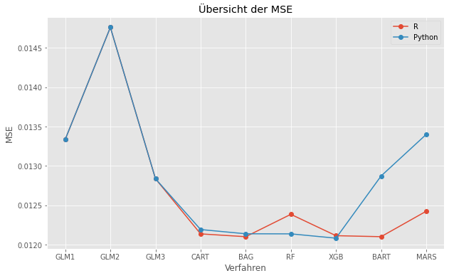

```python
# Plot 1
x = r_MSE['Methode']
y1 = pd.to_numeric(r_MSE['MSE'])
y2 = pd.to_numeric(python_MSE['MSE'])

diagramm = plt.figure(figsize=(10,6))
plt.style.use('ggplot')

plt.plot(x,y1, label="R",  linestyle='-', marker='o')
plt.plot(x,y2, label="Python",  linestyle='-', marker='o')
plt.title('Übersicht der MSE')
plt.ylabel('MSE')
plt.xlabel('Verfahren')
plt.legend()
plt.show()
```

Das zweite Diagramm basiert im wesentlichen auf der Idee einer direkten Gegenüberstellung der durchschnittlichen quadratischen Fehler der beiden Programmiersprachen. Hier ist besonders hervorzuheben, dass einige Modelle durchaus bessere Werte als andere liefern.

Betrachten wir zum Beispiel das Modell GLM 2 so erkennen wir, dass dieses im Vergleich zu den anderen Modellen schlechter abschneidet. Eines der Modelle, dass einen kleineren durchschnittlichen quadratischen Fehler liefert, ist zum Beispiel der Random Forest, mit dem wir uns im nächsten Abschnitt noch eingehender beschäftigen wollen.

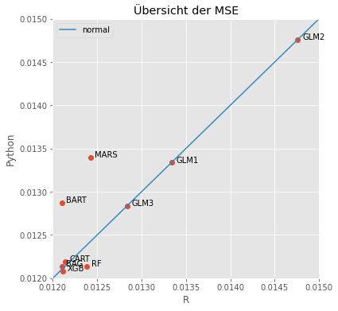

```python
# Plot 2
x = r_MSE['Methode']
y1 = pd.to_numeric(r_MSE['MSE'])
y2 = pd.to_numeric(python_MSE['MSE'])

diagramm = plt.figure(figsize=(6,6))
plt.style.use('ggplot')

plt.plot(y1,y2, 'o')
z = np.linspace(0.012, 0.015, 1000)
plt.plot(z, z, '-', label="normal")
plt.axis([0.012, 0.015, 0.012, 0.015])
total_rows = y1.size
for i in range(0, total_rows):
    if (not (np.isnan(y1[i]) or np.isnan(y2[i]))) and y1[i] <= 0.015 and y2[i] <= 0.015:
        plt.text(y1[i] + 0.00005 ,y2[i],str(x[i]))
plt.title('Übersicht der MSE')
plt.ylabel('Python')
plt.xlabel('R')
plt.legend()
plt.show()
```

Abschließend lässt sich festhalten, dass wir nur kleinere Unterschiede in den Ergebnissen der einzelnen Sprachen erkennen konnten. Daraus leiten wir ab, dass keine der Sprachen bessere Ergebisse liefert als die andere und somit beide Sprachen für die Arbeit im Rahmen der aktuariellen Welt geeignet sind.

Es lässt sich jedoch feststellen, dass die Modelle durchaus ihre Vorteile innerhalb verschiedener Einsatzgebiete haben. So sehen wir, dass der durchschnittliche quadratische Fehler bei einem GLM oberhalb anderer Modelle liegt, aber dieses Modell recht schnell umgesetzt werden kann und auch innerhalb einer kurzen Zeit annähernd gute Ergebnisse liefern kann. Benötigt man einen schnellen Überblick, so bietet sich die Bearbeitung mit einem GLM an.

Im nächsten Abschnitt wollen wir verdeutlichen, wie man Vorgehen kann, wenn man sich nicht sicher ist, was die beste Einstellung dieser Parameter ist.

# Analyse des Random Forest

Die obigen Ergebnisse zeigen, dass das Modell basierend auf dem Random Forest keine wesentlich besseren MSE aufweist als zum Beispiel die GLM´s, die zu Beginn des vorherigen Abschnitts eingeführt wurden. Dies ist überraschend, da die Random Forrest Modelle weit verbreitet sind. Das liegt zu einem daran, dass der Lernalgorithmus relativ einfach zu bedienen ist, und zum anderen an den relativ kurzen Trainingszeiten. (vgl. obige Ergebnisse unter Berücksichtigung der gemessenen Zeiten). Ist dies der ausschlagende Grund? Oder können wir am obigen Modell noch wesentliche Änderungen vornehmen, so dass der MSE im Vergleich zu den anderen Methoden deutlich sinkt? Wir versuchen dies an dieser Stelle mit Hilfe von zwei Möglichkeiten dies zu erreichen. Auf der einen Seite sind die ins Modell gegebenen Trainingsdaten entscheidend für den Erfolg des maschinellenen Lernens. D.h. wir werden zunächst versuchen die Daten zu analysieren. Die Ergebnisse der Analyse wollen wir benutzen, um ein besseres Ergebnis zu erreichen. Auf der anderen Seite ist die Definition der Variablen innerhalb des Modells wichtig. Welche Variablen sind wichtig für eine Verbesserung der Ergebnisse und welche Parameter sollten eingestellt werden.

## Analyse der Daten

Wir beginnen die Analyse der Daten zunächst auf der Basis des obigen Modells. Dies soll als Ausgangspunkt für die weitere Betrachtung dienen. Zusätzlich definieren wir bereits einige weitere Größen, die wir im Laufe der Betrachtung benötigen werden.

```python
# RF in der Analyse
if mitBerechnung:
    regressor = RandomForestRegressor(n_estimators=250, min_samples_split = 150, max_features=3)
    model = regressor.fit(x_train_ohe.values, y_train.values.ravel())

    importances = model.feature_importances_
    indices = np.argsort(importances)[::-1]
    columns = x_train_ohe.columns
    names = [columns[i] for i in indices]

    predictions = regressor.predict(x_test_ohe.values)

    mse_rf = ((predictions - datatest['Actual_Recovery_Rate'])**2).mean(axis=None)
else:
    mse_rf = 0.012137927171212553
# Output
output("RF", mse_rf, None)
```

```
RF: Erfolgreich ausgeführt
RF: Ergebnis mse = 0.012137927171212553
```

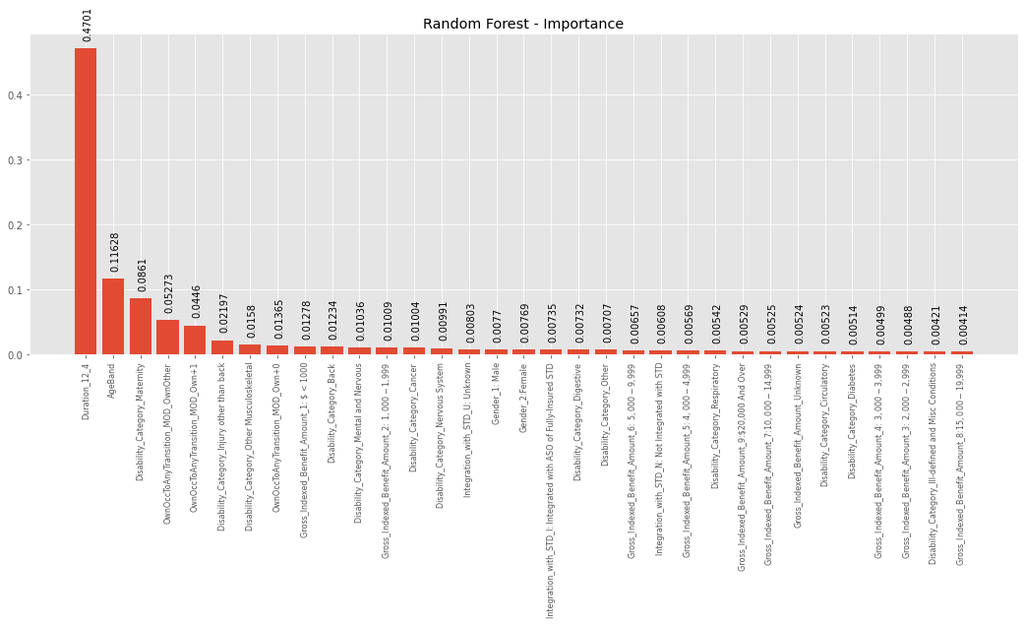

```python
diagramm = plt.figure(figsize=(18,6))
plt.style.use('ggplot')

if mitBerechnung:
    x = x_train_ohe.values.shape[1]
    y = np.round(importances[indices], 5)
else:
    x = 33
    y = [0.4701, 0.11628, 0.0861, 0.05273, 0.0446, 0.02197, 0.0158, 0.01365, 0.01278, 0.01234, 0.01036, 0.01009, 0.01004, 0.00991, 0.00803, 0.0077, 0.00769, 0.00735, 0.00732, 0.00707, 0.00657, 0.00608, 0.00569, 0.00542, 0.00529, 0.00525, 0.00524, 0.00523, 0.00514, 0.00499, 0.00488, 0.00421, 0.00414]
    names = ["Duration_12_4", "AgeBand", "Disability_Category_Maternity", "OwnOccToAnyTransition_MOD_OwnOther", "OwnOccToAnyTransition_MOD_Own+1", "Disability_Category_Injury other than back", "Disability_Category_Other Musculoskeletal", "OwnOccToAnyTransition_MOD_Own+0", "Gross_Indexed_Benefit_Amount_1: $ < 1000", "Disability_Category_Back", "Disability_Category_Mental and Nervous", "Gross_Indexed_Benefit_Amount_2: $1,000 - $1,999", "Disability_Category_Cancer", "Disability_Category_Nervous System", "Integration_with_STD_U: Unknown", "Gender_1: Male", "Gender_2:Female", "Integration_with_STD_I: Integrated with ASO of Fully-Insured STD", "Disability_Category_Digestive", "Disability_Category_Other", "Gross_Indexed_Benefit_Amount_6: $5,000 - $9,999","Integration_with_STD_N: Not Integrated with STD", "Gross_Indexed_Benefit_Amount_5: $4,000 - $4,999", "Disability_Category_Respiratory", "Gross_Indexed_Benefit_Amount_9:$20,000 And Over", "Gross_Indexed_Benefit_Amount_7:$10,000 - $14,999", "Gross_Indexed_Benefit_Amount_Unknown", "Disability_Category_Circulatory", "Disability_Category_Diabetes", "Gross_Indexed_Benefit_Amount_4: $3,000 - $3,999", "Gross_Indexed_Benefit_Amount_3: $2,000 - $2,999", "Disability_Category_Ill-defined and Misc Conditions", "Gross_Indexed_Benefit_Amount_8:$15,000 - $19,999"]


barlist = plt.bar(range(x), y)

plt.xticks(range(x), names, rotation=90, fontsize = 8)

for bar in barlist:
    yval = bar.get_height()
    plt.text(bar.get_x() + 0.3, yval + 0.015, yval, rotation = 90)

plt.title("Random Forest - Importance")
plt.ylabel('')

plt.show()
```

Wir sehen im vorangegangenen Diagramm die einzelnen Daten die in das Random Forest Modell eingeflossen sind. Die Analyse der Wichtigkeit der einzelnen Daten zeigt ganz deutlich, dass die Auswertung des Modells und dem daraus resultierenden durchschnittlichen quadratischen Fehler, nicht gleichmäßig auf den Daten verteilt ist, sondern, dass einige wenige Daten besonders stark in die Vorhersage eingegangen sind. Auf dieser Grundlagen wollen wir uns zunächst noch einmal dem Aufbau des Datensatzes 'recovery' nähern.

Schauen wir zunächst erneut auf den verwendeten Datensatz 'recovery'. Wir stellen fest, dass nicht alle gegebenen Informationen in den Modellen aus dem vorherigen Abschnitten benutzt wurden. Durch die ausfürhliche Vorstellung der Daten sehen wir, dass folgende Spalten des Datensatzes keine Verwendung gefunden haben:

- Taxability_Benefits
- Exposures
- Actual_Recoveries
- Expected_Recoveries
- Actual_Deaths
- Expected_Deaths

Wir wissen, dass zum Vorhersagen der 'Actual_Recovery_Rate' nur die weitere Information 'Taxability_Benefits' genutzt werden kann. An dieser Stelle ist nun die Frage: Wenn wir das Modell um 'Taxability_Benefits' erweitern und damit eine Vorhersage für die 'Actual_Recovery_Rate' durchführen, erhalten wir dadurch ein besseres Ergebnis? Dieser Fragestellung wollen wir nun nachgehen, indem wir zunächst ein Random Forest Modell ausführen, dass zusätzlich über diese Information verfügt, aber ansonsten mit dem Random Forrest Modell vergleichbar ist, dass wir zu Beginn dieses Abschnitts betrachtet haben.

```python
# RF in der Analyse inkl. zusätzlicher Information
if mitBerechnung:
    datatrain_ext = datatrain_full[['Actual_Recovery_Rate','AgeBand', 'Duration_12_49', 'Gross_Indexed_Benefit_Amount', 'Disability_Category', 'OwnOccToAnyTransition_MOD', 'Integration_with_STD', 'Gender', 'Taxability_Benefits']]
    datatest_ext = datatest_full[['Actual_Recovery_Rate','AgeBand', 'Duration_12_49', 'Gross_Indexed_Benefit_Amount', 'Disability_Category', 'OwnOccToAnyTransition_MOD', 'Integration_with_STD', 'Gender', 'Taxability_Benefits']]

    x_train_ext = datatrain_ext.loc[:, datatrain_ext.columns!='Actual_Recovery_Rate']
    x_train_ext_ohe = pd.get_dummies(x_train_ext)
    x_test_ext = datatest_ext.loc[:, datatest_ext.columns!='Actual_Recovery_Rate']
    x_test_ext_ohe = pd.get_dummies(x_test_ext)

    regressor_ext = RandomForestRegressor(n_estimators=250, min_samples_split = 150, max_features=3)
    model_ext = regressor_ext.fit(x_train_ext_ohe.values, y_train.values.ravel())

    importances_ext = model_ext.feature_importances_
    indices_ext = np.argsort(importances_ext)[::-1]
    columns_ext = x_train_ext_ohe.columns
    names_ext = [columns_ext[i] for i in indices_ext]

    predictions_ext = regressor_ext.predict(x_test_ext_ohe.values)

    mse_rf_ext = ((predictions_ext - datatest['Actual_Recovery_Rate'])**2).mean(axis=None)
else:
    mse_rf_ext = 0.01217558698151907

# Output
output("RF_ext", mse_rf_ext, None)
```

```
RF_ext: Erfolgreich ausgeführt
RF_ext: Ergebnis mse = 0.01217558698151907
```

Wenn wir nun die beiden Ergebnisse bzgl. der gemessenen MSE vergleichen, sehen wir, dass die Hinzunahme der weiteren Spalte aus den Daten keine wesentliche Verbesserung der Daten gebracht hat.

```python
diff = mse_rf - mse_rf_ext
print(diff)
```

```
-3.765981030651698e-05
```

Diese Erkenntnis wird durch die Analyse des Einflusses der unterschiedlichen Parameter auf das Modell unterstrichen. Wir sehen aufgrund des "One Hot Encoding"-Ansatzes, hier wird die zusätzliche Information 'Taxability' mit den jweiligen Ausprägungen binär codiert, d.h. die insgesamt vier verschiedenen Ausprägungen werden in separate Informationen aufgeteilt. In nachfolgendem Diagramm sind diese Informationen grün hervorgehoben. Wir erkennen auch, dass der Einfluss dieser codierten Informationen nur marginal ist und somit auch erkennbar ist, warum der MSE der beiden Modelle etwa gleichwertig ist.

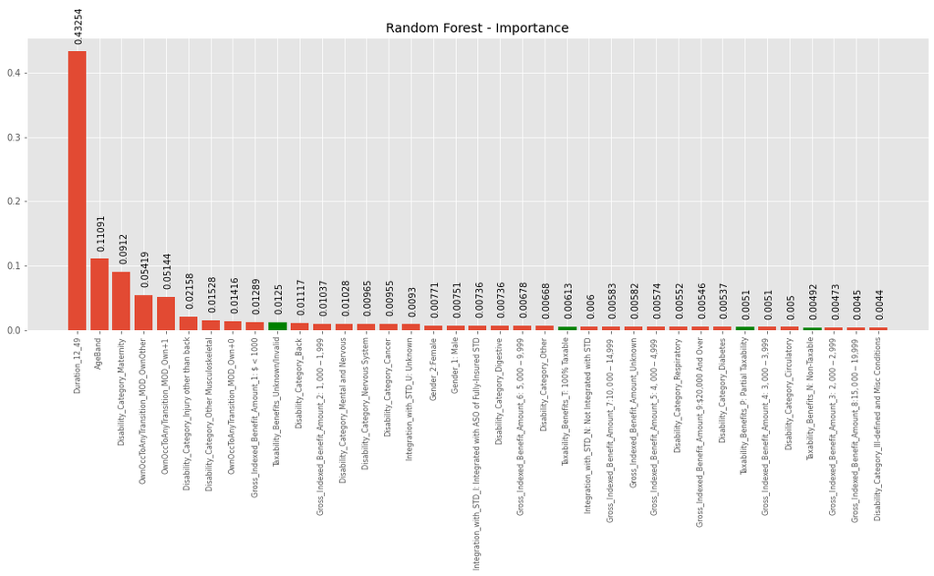

```python
diagramm = plt.figure(figsize=(18,6))
plt.style.use('ggplot')

if mitBerechnung:
    x = x_train_ext_ohe.values.shape[1]
    y = np.round(importances_ext[indices_ext], 5)
else:
    x = 37
    y = [0.43254, 0.11091, 0.0912, 0.05419, 0.05144, 0.02158, 0.01528, 0.01416, 0.01289, 0.0125, 0.01117, 0.01037, 0.01028, 0.00965, 0.00955, 0.0093, 0.00771, 0.00751, 0.00736, 0.00736, 0.00678, 0.00668, 0.00613, 0.006, 0.00583, 0.00582, 0.00574, 0.00552, 0.00546, 0.00537, 0.0051, 0.0051, 0.005, 0.00492, 0.00473, 0.0045, 0.0044]
    names_ext = ["Duration_12_49", "AgeBand", "Disability_Category_Maternity", "OwnOccToAnyTransition_MOD_OwnOther", "OwnOccToAnyTransition_MOD_Own+1", "Disability_Category_Injury other than back", "Disability_Category_Other Musculoskeletal", "OwnOccToAnyTransition_MOD_Own+0", "Gross_Indexed_Benefit_Amount_1: $ < 1000", "Taxability_Benefits_Unknown/Invalid", "Disability_Category_Back", "Gross_Indexed_Benefit_Amount_2: $1,000 - $1,999", "Disability_Category_Mental and Nervous", "Disability_Category_Nervous System", "Disability_Category_Cancer", "Integration_with_STD_U: Unknown", "Gender_2:Female", "Gender_1: Male", "Integration_with_STD_I: Integrated with ASO of Fully-Insured STD", "Disability_Category_Digestive", "Gross_Indexed_Benefit_Amount_6: $5,000 - $9,999", "Disability_Category_Other", "Taxability_Benefits_T: 100% Taxable", "Integration_with_STD_N: Not Integrated with STD", "Gross_Indexed_Benefit_Amount_7:$10,000 - $14,999", "Gross_Indexed_Benefit_Amount_Unknown", "Gross_Indexed_Benefit_Amount_5: $4,000 - $4,999", "Disability_Category_Respiratory", "Gross_Indexed_Benefit_Amount_9:$20,000 And Over", "Disability_Category_Diabetes", "Taxability_Benefits_P: Partial Taxability", "Gross_Indexed_Benefit_Amount_4: $3,000 - $3,999", "Disability_Category_Circulatory", "Taxability_Benefits_N: Non-Taxable", "Gross_Indexed_Benefit_Amount_3: $2,000 - $2,999", "Gross_Indexed_Benefit_Amount_8:$15,000 - $19,999", "Disability_Category_Ill-defined and Misc Conditions"]
barlist = plt.bar(range(x), y)

plt.xticks(range(x), names_ext, rotation=90, fontsize = 8)

for bar in barlist:
    yval = bar.get_height()
    plt.text(bar.get_x() + 0.3, yval + 0.015, yval, rotation = 90)

for i in range(x):
    if names_ext[i].startswith('Taxability'):
        barlist[i].set_color('g')

plt.title("Random Forest - Importance")
plt.ylabel('')

plt.show()
```

Durch die Hinzunahme der weiteren Information konnte also keine wesentliche Verbesserung der Ergebnisse erzielt werden, so dass wir wieder zum ursprünglichen Modell übergehen, welches auch im Abschnitt mit den Vergleichsmodellen entwickelt wurde. Da wir nur die vorliegenden Daten zur Verfügung haben und diese bereits eine komprimierte und reduzierte Darstellung der Rohdaten darstellen (vgl. [Studie von 2008](https://www.soa.org/globalassets/assets/Files/Research/Exp-Study/research-2008-ltd-gltd-table.pdf)), können wir an dieser Stelle abschließend nur eine Verbesserung der Ergebnisse erzielen, indem wir ein Bootstrapping-Verfahren anwenden. Dabei handelt es sich um ein statistisches Resampling Verfahren, das in seiner einfachsten Form durch ein "Ziehen mit Zurücklegen" beschrieben werden kann. Die Idee ist, dass wir mit Hilfe dieses Verfahrens bessere Ergebnisse erhalten. Ein Blick in die Dokumentation des RandomForrestRegressor des packages 'sklearn.ensemble' verrät, dass bereits eine Option des Bootstrapping verbaut ist (vgl. [sklearn.ensemble.RandomForestRegressor](https://scikit-learn.org/stable/modules/generated/sklearn.ensemble.RandomForestRegressor.html)). Die standardisierte Ausprägung dieser Option ist mit dem Wert 'True' vorbelegt, so dass das zugehörige Bootstrapping-Verfahren bereits bei den obigen Varianten ausgeführt wurde. Wir können also an dieser Stelle nur untersuchen, welche Ergebnisse wir erhalten, ohne ein solches Verfahren auszuführen.

```python
# RF in der Analyse ohne Bootstrapping
if mitBerechnung:
    regressor = RandomForestRegressor(n_estimators=250, min_samples_split = 150, max_features=3, bootstrap=False)
    model = regressor.fit(x_train_ohe.values, y_train.values.ravel())

    predictions = regressor.predict(x_test_ohe.values)

    mse_rf_false = ((predictions - datatest['Actual_Recovery_Rate'])**2).mean(axis=None)
else:
    mse_rf_false = 0.012124425920309888
# Output
output("RF_boot_false", mse_rf_false, None)
```

```
RF_boot_false: Erfolgreich ausgeführt
RF_boot_false: Ergebnis mse = 0.012124425920309888
```

```python
diff = mse_rf - mse_rf_false
print(diff)
```

```
1.3501250902664061e-05
```

Wir sehen als Resultat, dass auch die Möglichkeit des Bootstrapping, auf den uns zur Verfügung stehenden Daten, keine signifikante Verbesserung des Vorhersagefehlers erreichen konnte. Abschließend lässt sich also feststellen, dass mit den gegeben Daten keine weiteren Verbesserungen der Resultate erzielt werden konnten. Oder anders formuliert, wir waren nicht in der Lage durch die Hinzunahme einer weiteren Information einen signifikant verbesserten 'mean squared error' zu erzielen.

## Hyperparameter Tuning

Im vorherigen Abschnitt haben wir gesehen, dass wir aus den gegeben Daten keine Verbesserung des Vorhersagefehlers erzielen konnten. Da wir als Grundlage für unsere Analyse die gegebenen Daten verwenden wollen, können wir an dieser Stelle eine Verbesserung des Vorhersagefehlers nur noch durch eine bessere Kalibrierung des Modells erreichen.  
Doch zunächst wollen wir kurz erklären, was sich hinter dem Begriff 'Hyperparameter Tuning', auf deutsch auch 'Hyperparameteroptimierung' genannt, verbirgt. Der Begriff Hyperparameter bezieht sich auf die möglichen Parameter des Trainingsalgorithmus und ist damit abzugrenzen von den Parametern, die während des eigentlichen Trainings des Modells anhand der Trainingsdaten festgelegt werden. Dieses Einstellen der Parameter können wir uns auch metaphorisch als Sendersuche bei einem Radio vorstellen. Das Verstellen der Frequenz, ist dabei bildlich gesprochen, das Einstellen eines Hyperparameter. Zunächst wählt man eine Ausgangsfrequenz und variiert nun schrittweise auf Grundlage des ertönenden Radioempfangs diese Frequenz. Dies wiederholt man bis man abschließend zu einen guten Ergebnis gekommen ist, oder alternativ, bis eine Veränderung der Frequenz keine Verbesserung des Radioempfangs nach sich zieht. Wie in der Dokumentation zum package 'sklearn.ensemble' beschrieben, besitzt die Methode RandomForestRegressor eine Vielzahl an möglichen Parametern (vgl. [sklearn.ensemble.RandomForestRegressor](https://scikit-learn.org/stable/modules/generated/sklearn.ensemble.RandomForestRegressor.html) zur Einstellung des jeweiligen Modells. Doch genau hier ist auch bereits das Problem. Wie soll man im Vorfeld nur auf Grundlage der Daten entscheiden, welche Einstellungen der Hyperparameter gewählt werden sollen, um direkt das bestmögliche Ergebnis zu erhalten? Dies ist schier unmöglich. Daher wechseln wir im Bereich des 'Hyperparameter Tuning' von der Wissenschaft zum Ausprobieren. Man probiert also eine Vielzahl von möglichen Kombinationen der Hyperparameter aus, indem man die Modelle auf Grundlage dieser Einstellungen kalibirert und den zugehörigen Vorhersagefehler misst. Doch bei diesem Ansatz haben wir ein Problem. Es ist recht einfach erklärt, denn wir trainieren unser Modell auf Grundlage der Trainigsdaten. Auch beim Hyperparameter Tuning benutzen wir nur die Trainigsdaten. Die Testdaten werden erst für die Vorhersagen benutzt. D.h. wir wählen die Hyperparameter gerade so, dass wir auf Grundlage der Trainingsdaten eine bestmögliche Vorhersage erzielen. Allerdings ist unklar, wie sich diese Wahl der Hyperparameter auf die Testdaten auswirkt. Es kann passieren, dass das Modell sehr gute Vorhersagen auf den Trainingsdaten durchführt, aber nur eine schlechte Performance auf den Testdaten zeigt. Dieses Problem nennt man 'overfitting'. In den bisher benutzen Modellen haben wir immer die Hyperparameter so gewählt, wie wir sie zum Vergleich mit den Modellen in der Programmiersprache 'R' benutzt haben. Wir werden an dieser Stelle dazu übergehen keinen der Hyperparameter vorzubelegen und finden in dem nachfolgenden Beispiel heraus, welche Hyperparameter im Standardvorgehen benutzt werden.

```python
rf = RandomForestRegressor(random_state = 42)
print('Parameters currently in use:\n')
pprint(rf.get_params())
```

```
Parameters currently in use:

{'bootstrap': True,
 'ccp_alpha': 0.0,
 'criterion': 'mse',
 'max_depth': None,
 'max_features': 'auto',
 'max_leaf_nodes': None,
 'max_samples': None,
 'min_impurity_decrease': 0.0,
 'min_impurity_split': None,
 'min_samples_leaf': 1,
 'min_samples_split': 2,
 'min_weight_fraction_leaf': 0.0,
 'n_estimators': 100,
 'n_jobs': None,
 'oob_score': False,
 'random_state': 42,
 'verbose': 0,
 'warm_start': False}
```

Das sind vielleicht mehr Parameter als man zunächst erwartet hätte. Einige von den genannten sind bereits bekannt, andere unbekannt. Wie findet man nun die Hyperparameter, die einen entscheiden Einfluss auf die Vohersage der Modelle haben? Alternativ wäre es möglich mit allen diesen Parametern zu starten und somit auch herauszufinden, welche Parameter den entscheidensten Einfluss haben.

- n_estimators = number of trees in the forest
- max_features = max number of features considered for splitting a node
- max_depth = max number of levels in each decision tree
- min_samples_split = min number of data points placed in a node before the node is split
- min_samples_leaf = min number of data points allowed in a leaf node

Wir wählen für diese Parameter eine möglichst große Auswahl an Kalibirerungen die wir im Anschluss daran für eine Suche nach den besten Parametern benutzen wollen. Unsere Auswahl haben wir wie folgt getroffen:

```python
n_estimators = [100, 150, 200, 400, 600, 800, 1000, 1200, 1400, 1600, 1800, 2000]
max_features = ['sqrt']
max_depth = [int(x) for x in np.linspace(10, 110, num = 11)]
min_samples_split = [50, 100, 125, 150, 175, 200, 250, 300]
min_samples_leaf = [1, 2, 4, 8, 16, 24]

random_grid = {'n_estimators': n_estimators,
               'max_features': max_features,
               'max_depth': max_depth,
               'min_samples_split': min_samples_split,
               'min_samples_leaf': min_samples_leaf
              }
pprint(random_grid)
```

```
{'max_depth': [10, 20, 30, 40, 50, 60, 70, 80, 90, 100, 110],
 'max_features': ['sqrt'],
 'min_samples_leaf': [1, 2, 4, 8, 16, 24],
 'min_samples_split': [50, 100, 125, 150, 175, 200, 250, 300],
 'n_estimators': [100,
                  150,
                  200,
                  400,
                  600,
                  800,
                  1000,
                  1200,
                  1400,
                  1600,
                  1800,
                  2000]}
```

Nun analysieren wir für jeden dieser Hyperparameter die Auswirkungen auf die zu erzielenden Ergebnisse. Dazu betrachten wir einen standardisierten Random Forest, bei dem wir einen der obigen Hyperparameter einbringen und entsprechend unserer Auswahl verändern.

```python
def getPrediction_N_Estimators():
    n_estimators = [100, 150, 200, 400, 600, 800, 1000, 1200, 1400, 1600, 1800, 2000]
    if mitBerechnung:
        train_results = []
        test_results = []
        for estimator in n_estimators:
            rf = RandomForestRegressor(n_estimators=estimator, n_jobs=-1)
            rf.fit(x_train_ohe.values, y_train.values.ravel())
            train_pred = rf.predict(x_train_ohe.values)
            mse_train = mean_squared_error(train_pred, y_train)
            train_results.append(mse_train)
            test_pred = rf.predict(x_test_ohe.values)
            mse_test = mean_squared_error(test_pred, y_test)
            test_results.append(mse_test)
        print("done!")
    else:
        train_results = [0.005342041264383930, 0.0053264808191175400, 0.005316773422128830, 0.0053020827200227100, 0.005298723872469110, 0.005294535676550300, 0.0052947801324029200, 0.0052940073100805800, 0.00529224527764862, 0.005291781739515370, 0.005291640969860730, 0.005290671961213600]
        test_results = [0.015798919288405000, 0.015787426393295400, 0.015778847605019800, 0.01574739769698810, 0.015744049254123400, 0.015744072888633100, 0.01573609690736030, 0.01573560118532440, 0.015738821236662300, 0.01574254845739810, 0.01573572267187860, 0.015739351472915100]
    return (n_estimators, train_results, test_results)
```

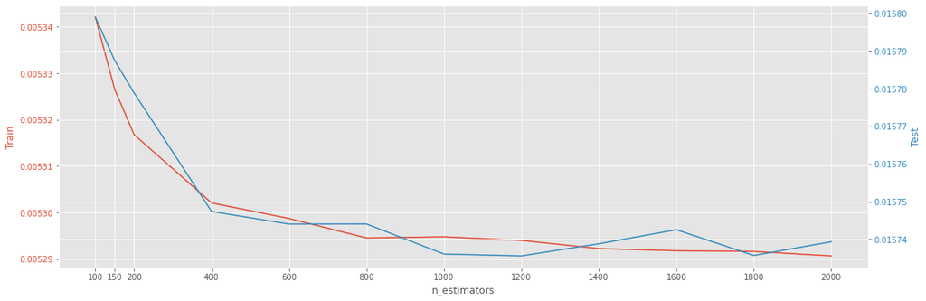

```python
# Plot - n_estimator
plt.style.use('ggplot')

(x, y1 ,y2) = getPrediction_N_Estimators()

diagramm, ax1 = plt.subplots(figsize=(18, 6))

color = '#E24A33'
ax1.set_xlabel('n_estimators')
ax1.set_ylabel('Train' , color=color)
ax1.plot(x, y1, color=color)
ax1.tick_params(axis='y', labelcolor=color)

ax2 = ax1.twinx()

color = '#348ABD'
ax2.set_ylabel('Test', color=color)
ax2.plot(x, y2, color=color)
ax2.tick_params(axis='y', labelcolor=color)

plt.xticks(x)
plt.show()
```

```python
def getPrediction_Min_Samples_Splits():
    min_samples_splits = [50, 100, 125, 150, 175, 200, 250, 300]
    if mitBerechnung:
        train_results = []
        test_results = []
        for samples_split in min_samples_splits:
            rf = RandomForestRegressor(min_samples_split=samples_split, n_jobs=-1)
            rf.fit(x_train_ohe.values, y_train.values.ravel())
            train_pred = rf.predict(x_train_ohe.values)
            mse_train = mean_squared_error(train_pred, y_train)
            train_results.append(mse_train)
            test_pred = rf.predict(x_test_ohe.values)
            mse_test = mean_squared_error(test_pred, y_test)
            test_results.append(mse_test)
    else:
        train_results = [0.010735437842069200, 0.011250717842914400, 0.011384832262341100, 0.01148265634233450, 0.01155735162963290, 0.011610059358956900, 0.01170601679840590, 0.011784996231501200]
        test_results = [0.012157421798059200, 0.01206201528877350, 0.012041032456754100, 0.012037577469556200, 0.012035900145246700, 0.012029610615243300, 0.012036092993637500, 0.01205728898802250]
    return (min_samples_splits, train_results, test_results)
```

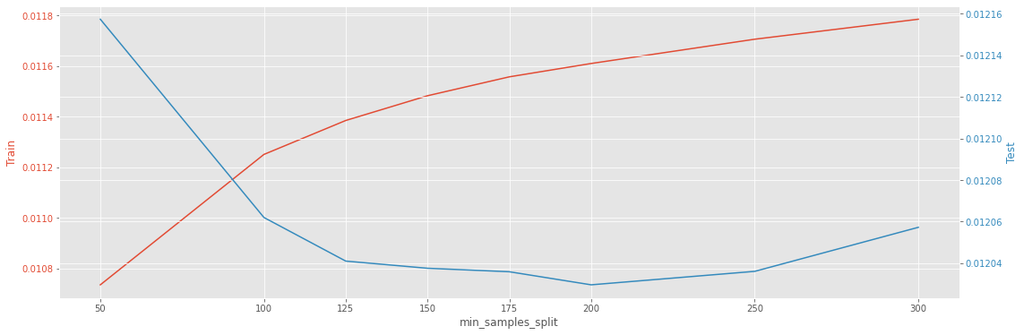

```python
# Plot - min_samples_split
plt.style.use('ggplot')

(x, y1 ,y2) = getPrediction_Min_Samples_Splits()

diagramm, ax1 = plt.subplots(figsize=(18, 6))

color = '#E24A33'
ax1.set_xlabel('min_samples_split')
ax1.set_ylabel('Train' , color=color)
ax1.plot(x, y1, color=color)
ax1.tick_params(axis='y', labelcolor=color)

ax2 = ax1.twinx()

color = '#348ABD'
ax2.set_ylabel('Test', color=color)
ax2.plot(x, y2, color=color)
ax2.tick_params(axis='y', labelcolor=color)

plt.xticks(x)
plt.show()
```

Hier lässt sich deutlich erkennen, dass der durchschnittliche quadratische Fehler auf der Trainingsmenge mit Zunahme der Werte deutlich ansteigt. Auf der Testmenge hingegen haben wir zunächst eine Verbesserung, die am Ende der Skala allerdings wieder in einem ansteigenden quadratischen Fehler resultiert. Daher wählen wir für unsere weiteren Betrachtungen die Menge beginnend bei 125 bis 250, unter Hinzunhame des weiteren Werts 225.

```python
def getPrediction_Max_Depths():
    max_depths = [int(x) for x in np.linspace(10, 110, num = 11)]
    if mitBerechnung:
        train_results = []
        test_results = []
        for depth in max_depths:
            rf = RandomForestRegressor(max_depth=depth, n_jobs=-1)
            rf.fit(x_train_ohe.values, y_train.values.ravel())
            train_pred = rf.predict(x_train_ohe.values)
            mse_train = mean_squared_error(train_pred, y_train)
            train_results.append(mse_train)
            test_pred = rf.predict(x_test_ohe.values)
            mse_test = mean_squared_error(test_pred, y_test)
            test_results.append(mse_test)
    else:
        train_results = [0.01173107880286860, 0.006923784449400560, 0.005378237789328430, 0.00534491552510019, 0.005343823606724510, 0.005341499937044560, 0.0053433433386073000, 0.005347726404402700, 0.005345536377698570, 0.0053420950625811700, 0.00534580650768231]
        test_results = [0.01211029258016290, 0.013950975900494700, 0.01571448576584070, 0.015822057286910500, 0.015811746817061800, 0.015805402334199400, 0.015803887445595800, 0.01578507846102060, 0.015802389077742700, 0.01582470513830860, 0.01582724380447090]
    return (max_depths, train_results, test_results)
```

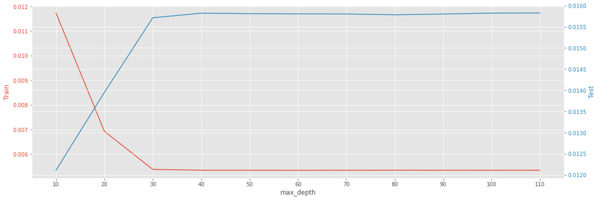

```python
# Plot - max_depths
plt.style.use('ggplot')

(x, y1 ,y2) = getPrediction_Max_Depths()

diagramm, ax1 = plt.subplots(figsize=(18, 6))

color = '#E24A33'
ax1.set_xlabel('max_depth')
ax1.set_ylabel('Train' , color=color)
ax1.plot(x, y1, color=color)
ax1.tick_params(axis='y', labelcolor=color)

ax2 = ax1.twinx()

color = '#348ABD'
ax2.set_ylabel('Test', color=color)
ax2.plot(x, y2, color=color)
ax2.tick_params(axis='y', labelcolor=color)

plt.xticks(x)
plt.show()
```

Der Hyperparameter 'max_depth' beschränkt im wesentlichen die Tiefe der Bäume innerhalb des Random Forest. Nach einhelliger Meinung sollte man diesen Parameter für eine möglichst aussagekräftige Bewertung nicht beschränken. Allerdings steigt mit der Tiefe der Bäume die benötigte Berechnungszeit, so dass es sinnvoll sein kann, in einigen Fällen eine Beschränkung vorzunehmen. Das vorangegangene Diagramm unterstreicht dies, da wir sehen, dass für größere Werte die Ergebnisse des Random Forest nicht wesentlich verändert werden. Wir werden dennoch diesen Hyperparameter in unseren Modellen nicht beschränken, da wir die Berechnungen auf einer anderen Maschine ausführen werden und die Dauer der Berechnungen in unserem Fall keine Rolle spielen.

```python
def getPrediction_Min_Samples_Leafs():
    min_samples_leafs = [1, 2, 4, 8, 16, 24, 32, 48]
    if mitBerechnung:
        train_results = []
        test_results = []
        for leafs in min_samples_leafs:
            rf = RandomForestRegressor(min_samples_leaf=leafs, n_jobs=-1)
            rf.fit(x_train_ohe.values, y_train.values.ravel())
            train_pred = rf.predict(x_train_ohe.values)
            mse_train = mean_squared_error(train_pred, y_train)
            #mse_train = ((train_pred - y_train)**2).mean(axis=None)
            train_results.append(mse_train)
            test_pred = rf.predict(x_test_ohe.values)
            mse_test = mean_squared_error(test_pred, y_test)
            #mse_test = ((test_pred - y_test)**2).mean(axis=None)
            test_results.append(mse_test)
    else:
        train_results = [0.005342041264383930, 0.00729622257790825, 0.009039979086927250, 0.010232387438883100, 0.010999459533349100, 0.01130805991928640, 0.011485263598531800, 0.011680837074353400]
        test_results = [0.015798919288405000, 0.013723320992159900, 0.012733200110103300, 0.012317362048937700, 0.012136002458493700, 0.012073601092528600, 0.01204720230604530, 0.012044789719469200]
    return (min_samples_leafs, train_results, test_results)
```

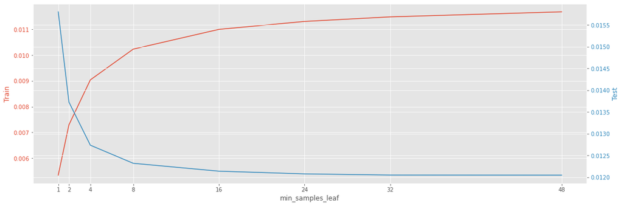

```python
# Plot - min_samples_leafs
plt.style.use('ggplot')

(x, y1 ,y2) = getPrediction_Min_Samples_Leafs()

diagramm, ax1 = plt.subplots(figsize=(18, 6))

color = '#E24A33'
ax1.set_xlabel('min_samples_leaf')
ax1.set_ylabel('Train' , color=color)
ax1.plot(x, y1, color=color)
ax1.tick_params(axis='y', labelcolor=color)

ax2 = ax1.twinx()

color = '#348ABD'
ax2.set_ylabel('Test', color=color)
ax2.plot(x, y2, color=color)
ax2.tick_params(axis='y', labelcolor=color)

plt.xticks(x)
plt.show()
```

Das vorangegangene Diagramm zeigt den Verlauf des Hyperparameters 'min_samples_leaf'. Dieser gibt an, wie viele Datensätze in Blättern eines Knoten enthalten sein müssen, damit dieser als Knoten berückschtigt wird. Mit einem steigenden Verlauf dieses Hyperparameters wird also der entsprechende Baum nach und nach gestutzt und führt so zu einfacheren Bäumen. Daraus resultiert dann eine Glättung des Modells. In unserem Fall haben wir ziemlich viele Datenpunkte, so dass der Einfluss dieses Parameters nicht direkt ersichtlich wird. Wir sehen allerdings im vorangegangenen Diagramm, dass eine Steigerung des Parameters zu einem Anstieg des durchschnittlichen quadratischen Fehlers in den Trainingsdaten führt, während die Ergebnisse der Tastdaten verbessert werden. Die durchschnittlichen quadratischen Fehler der Trainings- und der Testdaten nähern sich an. Wir werden diesen Auswahl unverändert in unsere Suche nach den besten Parametern übernehmen.

Zusammenfassend wollen wir die nachfolgenden Parameter benutzen, um die bestmögliche Wahl zu finden:

```python
n_estimators = [100, 150, 200, 400, 600, 800, 1000, 1200]
max_features = ['sqrt']
min_samples_split = [125, 150, 175, 200, 225, 250]
min_samples_leaf = [1, 2, 4, 8, 16, 24]

param_grid = {'n_estimators': n_estimators,
               'max_features': max_features,
               'min_samples_split': min_samples_split,
               'min_samples_leaf': min_samples_leaf
              }
pprint(param_grid)
```

```
{'max_features': ['sqrt'],
 'min_samples_leaf': [1, 2, 4, 8, 16, 24],
 'min_samples_split': [125, 150, 175, 200, 225, 250],
 'n_estimators': [100, 150, 200, 400, 600, 800, 1000, 1200]}
```

Diese Menge an Parametern wollen wir nun für eine Suche nach den besten Parametern berücksichtigen. Wir benutzen dazu das Tool 'GridSearchCV'. Dieses ermöglicht es uns das gewählte Grid zu übergeben und wird im Anschluss daran alle möglichen Kombinationen durchlaufen. Am Ende erhalten wir die Ergebnisse und können mit diesen die besten Parameter angeben.

Anmerkung: Im Folgenden sind immer mal wieder einige Codezeilen auskommentiert. Dies liegt im wesentlichen daran, dass die Berechnungen mit dem 'random_grid' nicht in Kaggle durchführbar sind, da diese zuviel Zeit beanspruchen. Wir haben daher alle Berechnungen in lokalen Umgebungen laufen lassen und stellen hier nur die jeweiligen Ergebnisse vor.

```python
rf = RandomForestRegressor()
grid_search = GridSearchCV(estimator = rf, param_grid = param_grid,
                          cv = 3, n_jobs = -1, verbose = 2, scoring="neg_mean_squared_error")
#grid_search.fit(x_train_ohe.values, y_train.values.ravel())
#results = grid_search.cv_results_
#results.to_csv('rf_grid.csv')
#grid_search.best_params_
#grid_search.to_csv('rf_grid_best.csv')
```

Mit dem obigen Grid dauert es sehr lange bis man die jeweiligen Berechnungen ausgeführt hat. Denn insgesamt haben wir an dieser Stelle 288 mögliche Kombinationen die geprüft werden sollen. Durch die 3-fache Kreuzvalidierung kommen wir auf insgesamt 864 nötige Fitting-Verfahren. Aus den Ergebnissen dieser Suche können wir nun die beste Kombination auswählen:

```python
#best_random = rf_random.best_estimator_
best_random = {'n_estimators': 1000, 'min_samples_split': 125, 'min_samples_leaf': 1, 'max_features': 'sqrt'}
pprint(best_random)
```

```
{'max_features': 'sqrt',
 'min_samples_leaf': 1,
 'min_samples_split': 125,
 'n_estimators': 1000}
```

Führen wir den Random Forest nochmals für diese Kombination aus, um den durchschnittlichen quadratischen Fehler für diese Kombination zu berechnen.

```python
# RF_best
if mitBerechnung:
    # Zeitmessung starten
    start_time = datetime.datetime.now()

    regressor = RandomForestRegressor(n_estimators=1000, min_samples_split=125, min_samples_leaf=1, max_features='sqrt')
    regressor.fit(x_train_ohe.values, y_train.values.ravel())

    predictions = regressor.predict(x_test_ohe.values)

    mse_rf_best = ((predictions - datatest['Actual_Recovery_Rate'])**2).mean(axis=None)

    # Zeitmessung beenden
    end_time = datetime.datetime.now()

    # verbrauchte Zeit berechnen
    elapsed_time = end_time - start_time
    t_rf_best = elapsed_time.total_seconds()
else:
    mse_rf_best = 0.01209225659854675
    t_rf_best = 153.292926

# Output
output("RF_best", mse_rf, None)
```

```
RF_best: Erfolgreich ausgeführt
RF_best: Ergebnis mse = 0.012137927171212553
```

```python
diff = mse_rf - mse_rf_best
print(diff)
```

```
4.567057266580306e-05
```

Wir sehen also, dass wir durch das Hyperparameter Tuning eine Verbesserung des durchschnittlichen quadratischen Fehlers erreichen konnten. Wie auch in den vorangegangenen Abschnitten haben wir auch in diesem eine feste Trainings- und Testmenge benutzt. Es ist zu erwarten, dass bei einer zufälligen Auswahl dieser Mengen und einigen Wiederholungen des Prozesses mit Schwankungen bei diesem Ergebnis zu rechnen ist.

# Erweiterung der Modellvielfalt um ein künstliches neuronales Netz

Ziel dieser Arbeit ist unter anderem die Ergänzung der verwendeten Methoden um ein künstliches neuronales Netz, da diese in der Vergangenheit in unterschiedlichen Einsatzbereichen bereits sehr gute Ergebnisse erzielt haben. Das Vorbild künstlicher neuronaler Netze ist das menschliche Gehirn, das durch die Verknüpfung von Milliarden von Neuronen in der Lage ist, zu lernen und so auf neue Situationen zu reagieren. Ein künstliches neuronales Netz besteht deshalb ebenso wie das menschliche Gehirn aus Neuronen, die über gerichtete und gewichtete Verbindungen miteinander vernetzt sind. Während des Trainings des Netzes lernt es den Zusammenhang zwischen Input und Output, so dass es später auch auf unbekannte Daten angewandt werden kann. Das Netz lernt, indem die Verbindungsgewichte zwischen den Neuronen verändert werden.

Es gibt eine Vielzahl unterschiedlicher Netze, die für verschiedene Anwendungsbereiche besonders geeignet sind. In diesem Fall haben wir uns für ein Feedforward-Netz entschieden, da diese einfache Form bereits ausreichen sollte, um den vorliegenden Zusammenhang abzubilden.

Bevor das Netz für seinen konkreten Anwendungsfall verwendet werden kann, muss es mit Hilfe von Trainingsdaten trainiert werden. Dazu werden die kategorischen Daten als Dummy-Variablen benötigt und die Trainingsdaten müssen nochmal in Trainings- und Validierungsdaten gesplittet werden. Der Anteil wurde so groß gewählt, dass das Validierungssample in etwa gleich viele Einträge enthält wie das Testsample.

```python
trainsample_nn= round(0.6*len(x_train_ohe))
x_train_nn = x_train_ohe.iloc[:trainsample_nn, :]
x_val_nn = x_train_ohe.iloc[trainsample_nn:]
y_train_nn = y_train.iloc[:trainsample_nn, :]
y_val_nn = y_train.iloc[trainsample_nn:]
```

Die Einstellungsmöglichkeiten für ein künstliches neuronales Netz sind vielschichtig. Die sogenannten Hyperparamter müssen a priori festgelegt werden. Sie umfassen beispielsweise die Anzahl der Hidden Schichten und die Anzahl der Neuronen auf den einzelnen Schichten. Wie schon beim Random Forest ist das sogenannte Hyperparameter Tuning von entscheidender Bedeutung. Um die Netzarchitektur zu optimieren, haben wir verschiedene Einstellungen von Hyperparametern mit Hilfe des Keras Tuners analysiert. Dabei werden die Einstellungen gewählt, die im Validierungssample das beste Ergebnis erzielt. Die folgenden Parameter haben wir getestet:

- Anzahl Hidden Schichten: 1, 2, 3
- Anzahl Neuronen: 17, 23, 64
- Aktivierungsfunktion: ReLu, tanh, Sigmoid
- Dropout-Rate: 0, 0.1, 0.2, 0.3, 0.4, 0.5
- Lernrate: 1e-2, 1e-3, 1e-4

Bei der Wahl der Neuronen-Anzahl haben wir uns an drei Faustregeln orientiert:

1. Die Anzahl sollte dem Mittelwert zwischen Input- und Output-Größe entsprechen: (33+1)/2 = 17
2. Die Anzahl sollte der Summe aus 2/3 der Anzahl der Input-Neuronen und der Anzahl der Output-Neuronen entsprechen: 22+1 = 23
3. Die Anzahl sollte nicht mehr als doppelt so hoch wie die Anzahl der Input-Neuronen sein. Außerdem performen Potenzen von 2 tendenziell besser. Deshalb haben wir uns als dritte Möglichkeit für 64 Neuronen entschieden.

Als Optimierer wurde der Adam-Optimierer gewählt. Die Einstellung der Dropout-Rate, der Anzahl der Neuronen und der Aktivierungsfunktion ist innerhalb eines Trials immer dieselbe für alle Hidden-Schichten. Das Training konnte sich maximal über 25 Epochen erstrecken. Das Training wird früher beendet, wenn drei Epochen hintereinander der Validierungsfehler nicht kleiner oder sogar größer geworden ist (Early Stopping mit Patience = 3). Die Batch-Size wurde aus Performance-Gründen auf 16 festgelegt. Aus diesen Einstellungsmöglichkeiten wurden dann insgesamt 100 zufällige Kombinationen getestet. Die Performance der einzelnen Netze wurde anhand des Mean-Squared-Errors des Validierungssamples gemessen.

```python
def hypermodel(hp):
    model = keras.Sequential()
    # Tune die Anzahl der Units: Wähle zwischen 17,23 und 64
    hp_units = hp.Choice('units', values=[17, 23, 64])

    # Tune die Aktivierungsfunktion: Wähle zwischen ReLu, tanh und Sigmoid
    actfunc = hp.Choice('dense_activation',
                    values=['relu', 'tanh', 'sigmoid'],
                    default='relu')
    model.add(keras.layers.Dense(units = hp_units, input_dim=33, activation=actfunc))

    #Tune die Dropout-Rate: Wähle einen optimalen Wert zwischen 0 und 0.5
    dropout = hp.Float('dropout', 0, 0.5, step=0.1, default=0.5)
    model.add(keras.layers.Dropout(dropout))

    # Tune die Anzahl der Hiddenschichten: Ingesamt sind zwischen 1 und 3 möglich
    for i in range(hp.Int('num_layers', 0, 2)):
      model.add(keras.layers.Dense(units=hp_units, activation=actfunc))
      model.add(keras.layers.Dropout(dropout))

    model.add(keras.layers.Dense(1, activation='sigmoid'))

    # Tune die Lernrate: zwischen 1e-2, 1e-3, 1e-4
    hp_learning_rate = hp.Choice('learning_rate', values = [1e-2, 1e-3, 1e-4])

    model.compile(optimizer = keras.optimizers.Adam(learning_rate = hp_learning_rate),
                loss = 'mse',
                metrics = ['accuracy'])

    return model



class ClearTrainingOutput(tf.keras.callbacks.Callback):
  def on_train_end(*args, **kwargs):
    IPython.display.clear_output(wait = True)


def KerasTuner():
    direc  ='RandomSearch_dir'
    tuner = kt.RandomSearch(
        hypermodel,
        objective='val_loss',
        seed=42,
        max_trials = 100,
        executions_per_trial= 1,
        directory=direc,
        project_name='RandomSearch'
    )
    epochs =25
    # Funktionsaufruf für die Suche nach den besten Hyperparametern:
    tuner.search(x_train_nn, y_train_nn, batch_size = 16, epochs = epochs, validation_data = (x_val_nn, y_val_nn),callbacks = [ClearTrainingOutput(), keras.callbacks.EarlyStopping('val_loss', patience=3)])
    # Beste Hyperparameter:
    best_hps = tuner.get_best_hyperparameters(num_trials = 1)[0]

    # Printe Eigenschaften der Suche & der Ergebnisse:
    tuner.search_space_summary()
    tuner.results_summary()

#KerasTuner()
```

Das beste gefundene künstliche neuronale Netz hat die folgenden Einstellungen:

- Anzahl Hidden Schichten: 2
- Anzahl Neuronen: 64
- Aktivierungsfunktion: Sigmoid
- Dropout-Rate: 0
- Lernrate: 1e-3

Es ist im nachfolgenden Code abgebildet. Es erzielt einen MSE in Höhe von 0.0121.

```python
def TrainFNN(num_units, act_func, learningRate, dropoutRate, num_layers):
    if mitBerechnung:
        model = keras.Sequential()
        # 1. Hidden-Schicht
        model.add(keras.layers.Dense(units=num_units, activation=act_func, input_shape=(33,)))
        model.add(keras.layers.Dropout(dropoutRate))
        # ggf. weitere hidden Schichten:
        for i in range(num_layers):
            model.add(keras.layers.Dense(units=num_units, activation=act_func))
            model.add(keras.layers.Dropout(dropoutRate))

        model.add(keras.layers.Dense(units=1, activation='sigmoid'))


        opti = keras.optimizers.Adam(learningRate)
        model.compile(optimizer=opti, loss= 'MSE')
        callbacks = []
        earlyStopping = keras.callbacks.EarlyStopping(monitor='val_loss', patience=3)
        callbacks.append(earlyStopping)

        model.fit(
            x_train_nn, y_train_nn,
            shuffle = True,
            epochs=25,
            validation_data=(x_val_nn, y_val_nn),
            callbacks= callbacks,
            batch_size= 16,
            verbose = 0
        )
        ypred = model.predict(x_test_ohe)

        mse_fnn = mean_squared_error(ypred, y_test)
    else:
        mse_fnn = 0.012136169058414551
    output("FNN", mse_fnn, None)
    return mse_fnn

# Lege Parameter fest:
num_units = 64
act_func = 'sigmoid'
learningRate = 0.001
dropoutRate = 0
num_layers = 1

# Zeitmessung starten
start_time =datetime.datetime.now()
#Trainiere das Netz
mse_fnn = TrainFNN(num_units, act_func, learningRate, dropoutRate, num_layers)
# Zeitmessung beenden
end_time = datetime.datetime.now()

# verbrauchte Zeit berechnen
elapsed_time = end_time - start_time
t_fnn = elapsed_time.total_seconds()
```

```
FNN: Erfolgreich ausgeführt
FNN: Ergebnis mse = 0.012136169058414551
```

# Zusammenfassung der Ergebnisse

Insgesamt verfolgte die Arbeit drei Ziele, deren Ergebnisse wir an dieser Stelle nochmal zusammenfassen möchten.

Der Vergleich zwischen den Programmiersprachen 'R' und 'Python' zeigt, dass die Ergebnisse nur minimal voneinander abweichen. Beide Sprachen sind somit für die Arbeit im Rahmen der aktuariellen Welt geeignet. Gerade bei den GLM´s ist zu erkennen, dass die Ergebnisse der beiden Programmiersprachen identisch sind. Dies liegt im Wesentlichen an der identischen Programmierung innerhalb der Programmiersprachen, da beide im wesentlichen FORTRAN Bibliotheken benutzen. Die Wahl der Programmiersprache ist also nur abhängig vom persönlichen Geschmack der Entwickler.

Der Random Forest ist eines der meistgenutzten Tools im Rahmen von Data Science. Wir konnten mit einigem Aufwand erreichen, dass mit einer optimierten Wahl von Parametern der durchschnittliche quadratische Fehler minimiert wurde. Es soll aber nicht verschwiegen werden, dass diese Arbeit nicht ohne Mühen verlaufen ist und es daher zu entscheiden ist, ob der Einsatz der Zeit sinnvoll erscheint. Wir sehen aber, dass durch das Hyperparameter Tuning die Ergebnisse verbessert werden konnten. Im Gegensatz zu den einfacheren Methoden, wie zum Beispiel eines GLM, kommt es beim Random Forest auf die Wahl der Parameter an. Mit der richtigen Kalibrierung kann am Ende das Maximum herausgeholt werden. Das geht dabei aber deutlich zu Lasten der Entwicklungszeit die benötigt wird, um diese optimale Einstellung zu finden.

Insgesamt lässt sich feststellen, dass je nach Einsatzzweck überprüft werden muss, welches Modell angemessen ist. Das GLM weist den schlechtesten MSE der getesteten Modell auf - es lässt sich jedoch sehr schnell umsetzen, verstehen und gut interpretieren. Insbesondere beim Random Forest und dem künstlichen neuronalen Netz nimmt die Suche nach den richtigen Hyperparamtern viel Zeit in Anspruch, so dass für jeden Einsatzzweck individuell abgewogen werden muss, ob der Mehraufwand im Verhältnis zu der besseren Prognose steht.

Abschließend geben wir noch einmal eine grafische Darstellung der einzelnen durchschnittlichen quadratischen Fehler aus dieser Arbeit an.

```python
MSE_data = [('GLM1', mse_glm1 , t_glm1 , 'sec' ) ,
         ('GLM2', mse_glm2 , t_glm2 , 'sec' ) ,
         ('GLM3', mse_glm3 , t_glm3 , 'sec' ) ,
         ('CART', mse_cart , t_cart , 'sec' ) ,
         ('BAG', mse_bag , t_bag , 'sec' ) ,
         ('RF', mse_rf , t_rf , 'sec' ) ,
         ('XGB', mse_xgb , t_xgb , 'sec' ) ,
         ('BART', mse_bart , t_bart , 'sec' ) ,
         ('MARS', mse_mars , t_mars , 'sec' ) ,
         ('RF_best', mse_rf_best , t_rf_best , 'sec' ) ,
         ('FNN', mse_fnn , t_fnn , 'sec' )]
MSE = pd.DataFrame(MSE_data, columns=["Methode", "MSE", "Zeit", "Einheit"])
```

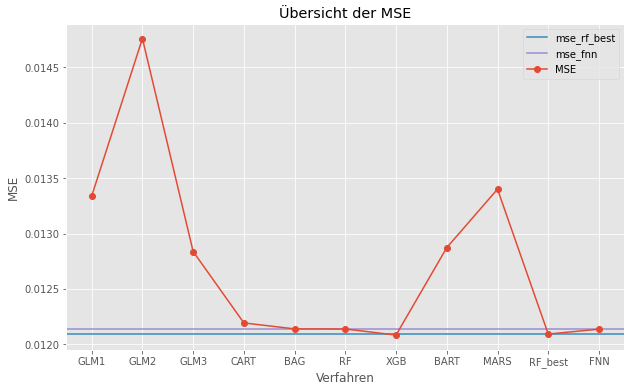

```python
x = MSE['Methode']
y = pd.to_numeric(MSE['MSE'])

diagramm = plt.figure(figsize=(10,6))
plt.style.use('ggplot')

plt.axhline(y=mse_rf_best, color = "#348ABD", label = "mse_rf_best")
plt.axhline(y=mse_fnn, color = "#988ED5", label = "mse_fnn")

plt.plot(x, y, linestyle='-', marker='o', label = "MSE")
plt.title('Übersicht der MSE')
plt.ylabel('MSE')
plt.xlabel('Verfahren')
plt.legend()
plt.show()
```

# Links

Im folgenden geben wir eine kurze Zusammenfassung der im Text verwendeten Links an.

- Alex Diana, Jim E. Griffin, Jaideep Oberoi and Aji Yao - Machine-Learning Methods for Insurance Applications - A Survey
  - Studie: https://www.soa.org/globalassets/assets/files/resources/research-report/2019/machine-learning-methods.pdf
  - Jupyter Notebook: https://www.soa.org/globalassets/assets/files/resources/research-report/2019/group-ltc-jupyter-file.zip
  - Datensatz: https://www.soa.org/globalassets/assets/files/resources/research-report/2019/group-ltd-data-set.zip
- Mervyn Kopinsky - Predicting Group Long Term Disability Recovery and Mortality Rates using Tree Models
  - Übersicht: https://www.soa.org/resources/experience-studies/2017/2017-gltd-recovery-mortality-tree/
  - Studie: https://www.soa.org/globalassets/assets/files/research/projects/2017-gltd-recovery-mortality-tree.pdf
- Roger Martin (Committee Chair), Barry Allen, Edd Bailey, Andy Baillargeon, Warren Cohen, Tom Corcoran, Fred Flores, Steve Garfield, Geoff Gerow, Scott Haglund, Paul Hitchcox, Rick Leavitt, Al Livingood, Ray Marra, Jacob McCoy, Eric Poirier, Ray Siwek, Ali Zaidi, Feng Zhao - 2008 Group Long Term Disability (Experience Table Report)
  - Studie: https://www.soa.org/globalassets/assets/Files/Research/Exp-Study/research-2008-ltd-gltd-table.pdf